# Tugas Praktikum 1 - Smoothing (Microsoft Monthly Stock Price, 2013-2023)

Muhammad Luthfi Al Gifari

2023-09-03

```r
library("forecast")
```

```r
library("graphics")
library("TTR")
library("TSA")
```

# Import Data

```r
library(rio)
Micros <- import("https://raw.githubusercontent.com/Mluthfialgifari/Praktikum-MPDW-Sems5/main/microsoft-stock-dataset-Monthly2.csv")
Micros
```

```
##          Date  Price
## 1    5/1/2013  32.93
## 2    6/1/2013  34.92
## 3    7/1/2013  34.75
## 4    8/1/2013  32.06
## 5    9/1/2013  31.75
## 6   10/1/2013  33.35
## 7   11/1/2013  35.67
## 8   12/1/2013  38.09
## 9    1/1/2014  37.35
## 10   2/1/2014  37.74
## 11   3/1/2014  37.92
## 12   4/1/2014  41.15
## 13   5/1/2014  40.24
## 14   6/1/2014  40.95
```

[output cut: 106 more lines]

```r
View(Micros)
Micros <- as.data.frame(Micros)
Micros
```

```
##          Date  Price
## 1    5/1/2013  32.93
## 2    6/1/2013  34.92
## 3    7/1/2013  34.75
## 4    8/1/2013  32.06
## 5    9/1/2013  31.75
## 6   10/1/2013  33.35
## 7   11/1/2013  35.67
## 8   12/1/2013  38.09
## 9    1/1/2014  37.35
## 10   2/1/2014  37.74
## 11   3/1/2014  37.92
## 12   4/1/2014  41.15
## 13   5/1/2014  40.24
## 14   6/1/2014  40.95
```

[output cut: 106 more lines]

# Eksplorasi Data

```r
str(Micros)
```

```
## 'data.frame':    120 obs. of  2 variables:
##  $ Date : chr  "5/1/2013" "6/1/2013" "7/1/2013" "8/1/2013" ...
##  $ Price: num  32.9 34.9 34.8 32.1 31.8 ...
```

```r
dim(Micros)
```

```
## [1] 120   2
```

# Scanning Data Deret Waktu

```r
Micros1.ts <- as.data.frame(ts(Micros$Price))
Micros1.ts
```

```
##          x
## 1    32.93
## 2    34.92
## 3    34.75
## 4    32.06
## 5    31.75
## 6    33.35
## 7    35.67
## 8    38.09
## 9    37.35
## 10   37.74
## 11   37.92
## 12   41.15
## 13   40.24
## 14   40.95
```

[output cut: 106 more lines]

# Ringkasan Data

```r
summary(Micros1.ts)
```

```
##        x
##  Min.   : 31.75
##  1st Qu.: 49.65
##  Median : 94.39
##  Mean   :128.86
##  3rd Qu.:213.75
##  Max.   :335.35
```

# Plot Data Deret Waktu

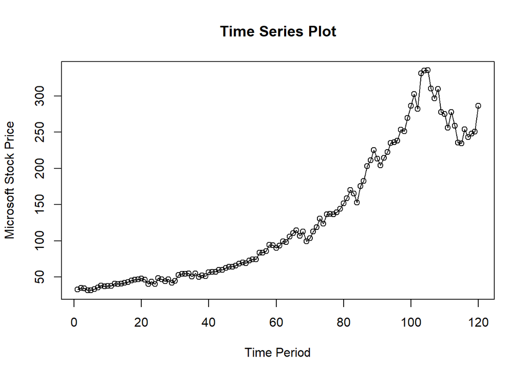

```r
ts.plot(Micros1.ts, xlab = "Time Period", ylab = "Microsoft Stock Price",
        main = "Time Series Plot")
points(Micros1.ts)
```

# Perbandingan Data Latih (80%) dan Data Uji (20%)

```r
# Pembagian Data Latih dan Data Uji
training_ma <- Micros[1:96,2]
training_ma
```

```
##  [1]  32.93  34.92  34.75  32.06  31.75  33.35  35.67  38.09  37.35  37.74
## [11]  37.92  41.15  40.24  40.95  41.86  43.21  45.43  46.27  46.89  47.88
## [21]  46.66  40.59  43.67  40.60  48.58  47.06  44.46  46.98  42.17  44.75
## [31]  52.85  54.41  54.32  54.88  50.97  55.05  50.00  52.44  51.13  56.60
## [41]  57.01  57.41  59.97  60.11  62.79  64.36  64.13  65.81  68.68  70.24
## [51]  69.33  73.10  74.71  74.71  83.68  83.60  86.13  94.79  93.99  90.47
## [61]  93.21  99.28  98.10 106.03 110.85 114.75 107.05 113.00  99.55 103.78
## [71] 112.89 118.95 130.53 123.85 136.63 137.00 136.61 139.66 144.26 151.81
## [81] 158.78 170.43 165.31 153.00 175.80 182.54 203.14 211.52 225.51 213.49
## [91] 204.29 214.51 222.53 235.06 235.90 238.47
```

```r
testing_ma <- Micros[97:120,2]
testing_ma
```

```
##  [1] 253.40 251.23 269.61 286.36 302.87 282.12 331.36 335.13 335.35 310.41
## [11] 296.40 309.37 277.71 275.20 256.39 277.82 258.87 235.41 234.60 253.87
## [21] 243.08 248.00 250.76 286.52
```

```r
train_ma.ts <- ts(training_ma)
train_ma.ts
```

```
## Time Series:
## Start = 1
## End = 96
## Frequency = 1
##  [1]  32.93  34.92  34.75  32.06  31.75  33.35  35.67  38.09  37.35  37.74
## [11]  37.92  41.15  40.24  40.95  41.86  43.21  45.43  46.27  46.89  47.88
## [21]  46.66  40.59  43.67  40.60  48.58  47.06  44.46  46.98  42.17  44.75
## [31]  52.85  54.41  54.32  54.88  50.97  55.05  50.00  52.44  51.13  56.60
## [41]  57.01  57.41  59.97  60.11  62.79  64.36  64.13  65.81  68.68  70.24
## [51]  69.33  73.10  74.71  74.71  83.68  83.60  86.13  94.79  93.99  90.47
## [61]  93.21  99.28  98.10 106.03 110.85 114.75 107.05 113.00  99.55 103.78
## [71] 112.89 118.95 130.53 123.85 136.63 137.00 136.61 139.66 144.26 151.81
## [81] 158.78 170.43 165.31 153.00 175.80 182.54 203.14 211.52 225.51 213.49
## [91] 204.29 214.51 222.53 235.06 235.90 238.47
```

```r
test_ma.ts <- ts(testing_ma)
test_ma.ts
```

```
## Time Series:
## Start = 1
## End = 24
## Frequency = 1
##  [1] 253.40 251.23 269.61 286.36 302.87 282.12 331.36 335.13 335.35 310.41
## [11] 296.40 309.37 277.71 275.20 256.39 277.82 258.87 235.41 234.60 253.87
## [21] 243.08 248.00 250.76 286.52
```

# Eksplorasi Data (Data Latih & Data Uji)

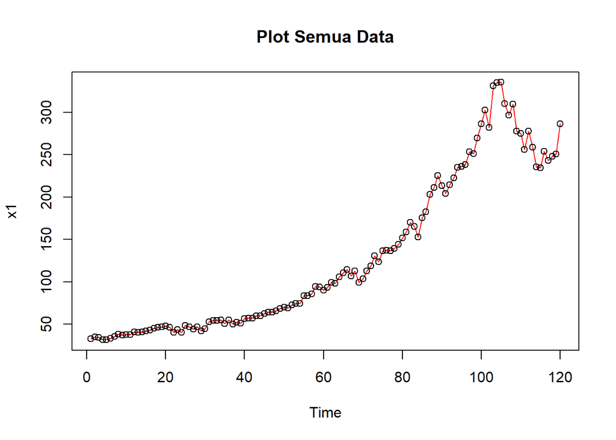

```r
# Eksplorasi Keseluruhan Data
plot(Micros1.ts, col = "red", main = "Plot Semua Data")
points(Micros1.ts)
```

```r
dev.copy(png, "Plot Keseluruhan Data.png")
```

```r
dev.off()
```

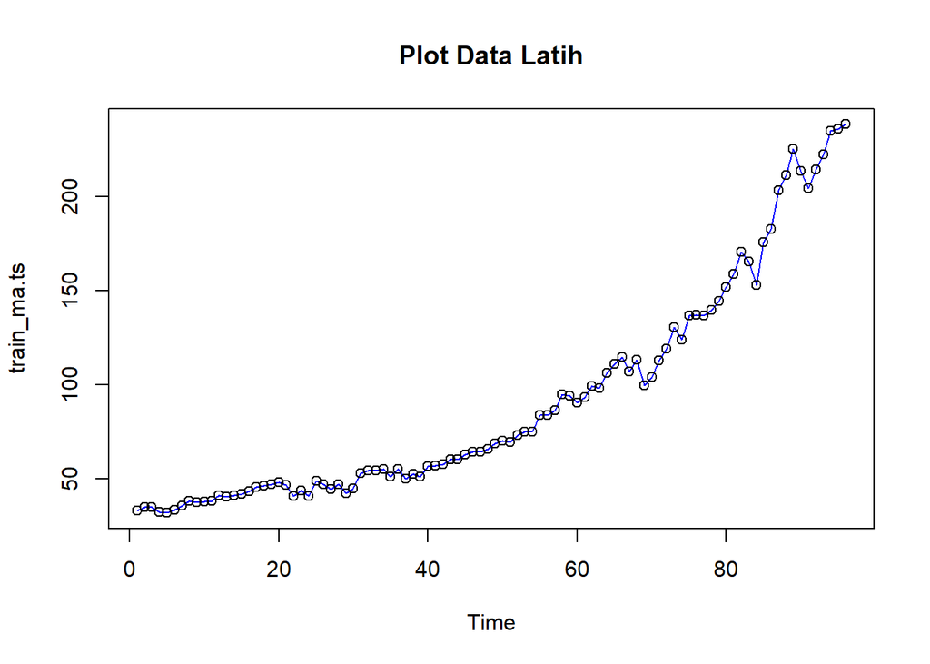

```r
# Eksplorasi Data Latih
plot(train_ma.ts, col = "blue", main = "Plot Data Latih")
points(train_ma.ts)
```

```r
dev.copy(png, "Plot Data Latih.png")
```

```r
dev.off()
```

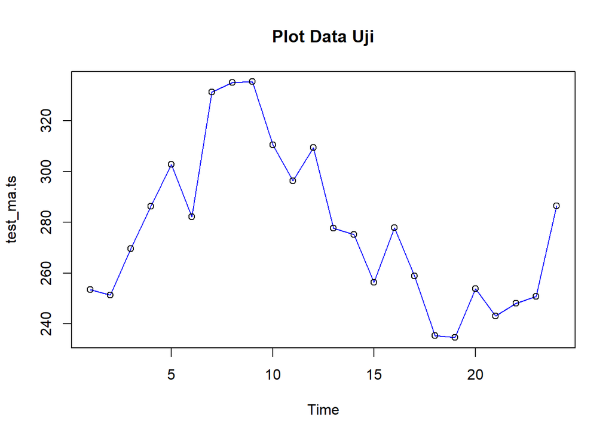

```r
# Eksplorasi Data Uji
plot(test_ma.ts, col = "blue", main = "Plot Data Uji")
points(test_ma.ts)
```

```r
dev.copy(png, "Plot Data Uji.png")
```

```r
dev.off()
```

# Eksplorasi Data (GGPLOT2)

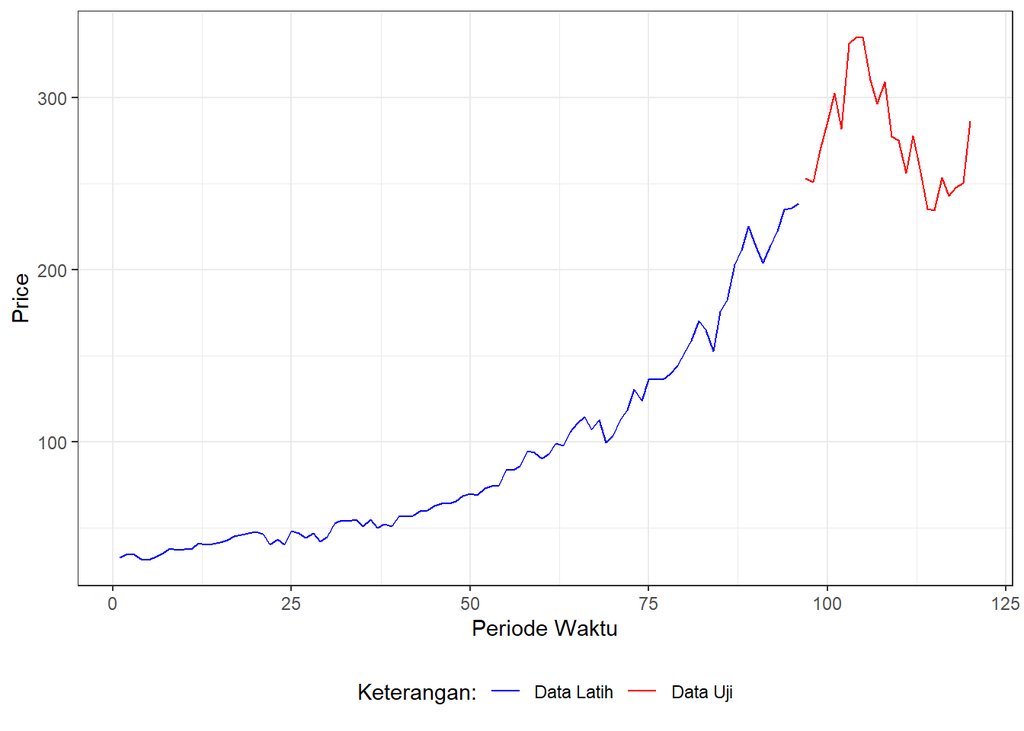

```r
Micros$no <- 1:nrow(Micros)
datagplot <- Micros[1:96,c(2,3)]
datagplot1 <- Micros[97:120,c(2,3)]
library(ggplot2)
ggplot() +
  geom_line(data = datagplot, aes(x = no, y = Price, col = "Data Latih")) +
  geom_line(data = datagplot1, aes(x = no, y = Price, col = "Data Uji")) +
  labs(x = "Periode Waktu", y = "Price", color = "Legend") +
  scale_colour_manual(name="Keterangan:", breaks = c("Data Latih", "Data Uji"),
                      values = c("blue", "red")) +
  theme_bw() + theme(legend.position = "bottom",
                     plot.caption = element_text(hjust=0.5, size=12))
```

## Single Moving Average

```r
# SMA dengan parameter 'm = 4'
data.sma <- SMA(train_ma.ts, n = 4)
data.sma
```

```
## Time Series:
## Start = 1
## End = 96
## Frequency = 1
##  [1]       NA       NA       NA  33.6650  33.3700  32.9775  33.2075  34.7150
##  [9]  36.1150  37.2125  37.7750  38.5400  39.2625  40.0650  41.0500  41.5650
## [17]  42.8625  44.1925  45.4500  46.6175  46.9250  45.5050  44.7000  42.8800
## [25]  43.3600  44.9775  45.1750  46.7700  45.1675  44.5900  46.6875  48.5450
## [33]  51.5825  54.1150  53.6450  53.8050  52.7250  52.1150  52.1550  52.5425
## [41]  54.2950  55.5375  57.7475  58.6250  60.0700  61.8075  62.8475  64.2725
## [49]  65.7450  67.2150  68.5150  70.3375  71.8450  72.9625  76.5500  79.1750
## [57]  82.0300  87.0500  89.6275  91.3450  93.1150  94.2375  95.2650  99.1550
## [65] 103.5650 107.4325 109.6700 111.4125 108.5875 105.8450 107.3050 108.7925
## [73] 116.5375 121.5550 127.4900 132.0025 133.5225 137.4750 139.3825 143.0850
## [81] 148.6275 156.3200 161.5825 161.8800 166.1350 169.1625 178.6200 193.2500
## [89] 205.6775 213.4150 213.7025 214.4500 213.7050 219.0975 227.0000 232.9900
```

Data pemulusan pada periode ke-t selanjutnya digunakan sebagai nilai peramalan pada periode ke t+1 sehingga hasil peramalan 1 periode kedepan adalah sebagai berikut:

```r
data.ramal1 <- c(NA, data.sma)
data.ramal1 # Peramalan 1 periode ke depan
```

```
##  [1]       NA       NA       NA       NA  33.6650  33.3700  32.9775  33.2075
##  [9]  34.7150  36.1150  37.2125  37.7750  38.5400  39.2625  40.0650  41.0500
## [17]  41.5650  42.8625  44.1925  45.4500  46.6175  46.9250  45.5050  44.7000
## [25]  42.8800  43.3600  44.9775  45.1750  46.7700  45.1675  44.5900  46.6875
## [33]  48.5450  51.5825  54.1150  53.6450  53.8050  52.7250  52.1150  52.1550
## [41]  52.5425  54.2950  55.5375  57.7475  58.6250  60.0700  61.8075  62.8475
## [49]  64.2725  65.7450  67.2150  68.5150  70.3375  71.8450  72.9625  76.5500
## [57]  79.1750  82.0300  87.0500  89.6275  91.3450  93.1150  94.2375  95.2650
## [65]  99.1550 103.5650 107.4325 109.6700 111.4125 108.5875 105.8450 107.3050
## [73] 108.7925 116.5375 121.5550 127.4900 132.0025 133.5225 137.4750 139.3825
## [81] 143.0850 148.6275 156.3200 161.5825 161.8800 166.1350 169.1625 178.6200
## [89] 193.2500 205.6775 213.4150 213.7025 214.4500 213.7050 219.0975 227.0000
## [97] 232.9900
```

Selanjutnya akan dilakukan peramalan sejumlah data uji yaitu 24 periode. Pada metode SMA, hasil peramalan 24 periode ke depan akan bernilai sama dengan hasil peramalan 1 periode kedepan. Dalam hal ini akan dilakukan pengguabungan data aktual train, data hasil pemulusan dan data hasil ramalan 24 periode kedepan.

```r
data.gab1 <- cbind(aktual = c(train_ma.ts, rep(NA, 24)), pemulusan = c(data.sma, rep(NA, 24)), ramalan = c(data.ramal1, rep(data.ramal1[length(data.ramal1)], 23)))
data.gab1 # Peramalan 24 periode ke depan
```

```
##        aktual pemulusan  ramalan
##   [1,]  32.93        NA       NA
##   [2,]  34.92        NA       NA
##   [3,]  34.75        NA       NA
##   [4,]  32.06   33.6650       NA
##   [5,]  31.75   33.3700  33.6650
##   [6,]  33.35   32.9775  33.3700
##   [7,]  35.67   33.2075  32.9775
##   [8,]  38.09   34.7150  33.2075
##   [9,]  37.35   36.1150  34.7150
##  [10,]  37.74   37.2125  36.1150
##  [11,]  37.92   37.7750  37.2125
##  [12,]  41.15   38.5400  37.7750
##  [13,]  40.24   39.2625  38.5400
##  [14,]  40.95   40.0650  39.2625
```

[output cut: 106 more lines]

# Plot Deret Waktu (Hasil Peramalan)

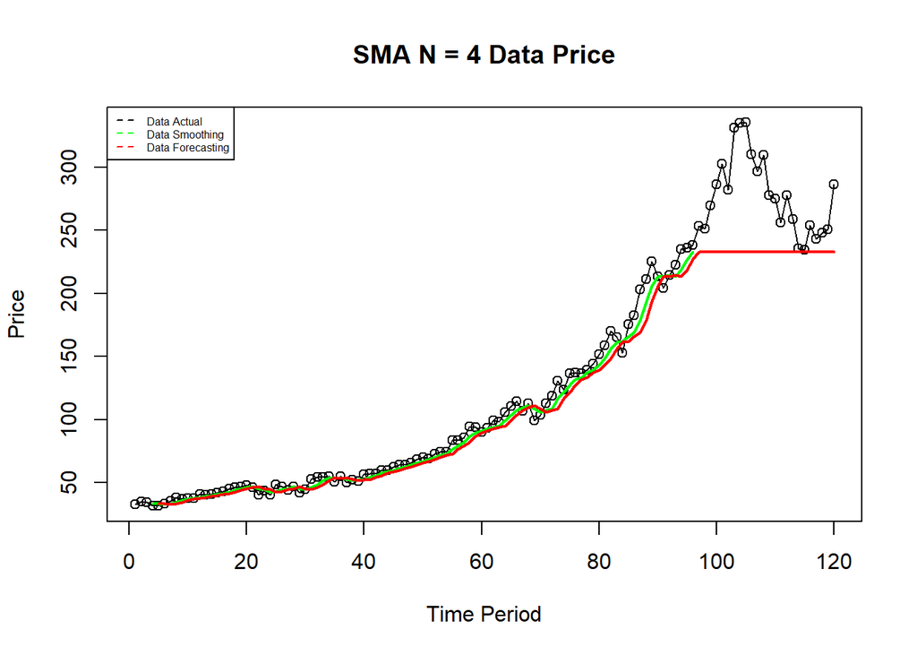

```r
ts.plot(Micros1.ts, xlab = "Time Period", ylab = "Price", main = "SMA N = 4 Data Price")
points(Micros1.ts)
lines(data.gab1[,2], col = "green", lwd = 2)
lines(data.gab1[,3], col = "red", lwd = 2)
legend("topleft", c("Data Actual", "Data Smoothing", "Data Forecasting"), lty = 8, col = c("black", "green", "red"), cex = 0.5)
```

# Ukuran Akurasi (Metode SSE, MSE, MAPE) Data Latih & Data Uji

```r
# Menghitung Nilai Keakuratan Data Latih
error_train.sma = train_ma.ts-data.ramal1[1:length(train_ma.ts)]
error_train.sma
```

```
## Time Series:
## Start = 1
## End = 96
## Frequency = 1
##  [1]       NA       NA       NA       NA  -1.9150  -0.0200   2.6925   4.8825
##  [9]   2.6350   1.6250   0.7075   3.3750   1.7000   1.6875   1.7950   2.1600
## [17]   3.8650   3.4075   2.6975   2.4300   0.0425  -6.3350  -1.8350  -4.1000
## [25]   5.7000   3.7000  -0.5175   1.8050  -4.6000  -0.4175   8.2600   7.7225
## [33]   5.7750   3.2975  -3.1450   1.4050  -3.8050  -0.2850  -0.9850   4.4450
## [41]   4.4675   3.1150   4.4325   2.3625   4.1650   4.2900   2.3225   2.9625
## [49]   4.4075   4.4950   2.1150   4.5850   4.3725   2.8650  10.7175   7.0500
## [57]   6.9550  12.7600   6.9400   0.8425   1.8650   6.1650   3.8625  10.7650
## [65]  11.6950  11.1850  -0.3825   3.3300 -11.8625  -4.8075   7.0450  11.6450
## [73]  21.7375   7.3125  15.0750   9.5100   4.6075   6.1375   6.7850  12.4275
## [81]  15.6950  21.8025   8.9900  -8.5825  13.9200  16.4050  33.9775  32.9000
## [89]  32.2600   7.8125  -9.1250   0.8075   8.0800  21.3550  16.8025  11.4700
```

```r
SSE_train.sma = sum(error_train.sma[5:length(train_ma.ts)]^2)
SSE_train.sma
```

```
## [1] 8676.411
```

```r
MSE_train.sma = mean(error_train.sma[5:length(train_ma.ts)]^2)
MSE_train.sma
```

```
## [1] 94.30881
```

```r
MAPE_train.sma = mean(abs((error_train.sma[5:length(train_ma.ts)]/train_ma.ts[5:length(train_ma.ts)])*100))
MAPE_train.sma
```

```
## [1] 6.855884
```

```r
akurasi_train.sma <- matrix(c(SSE_train.sma, MSE_train.sma, MAPE_train.sma))
akurasi_train.sma
```

```
##             [,1]
## [1,] 8676.410919
## [2,]   94.308814
## [3,]    6.855884
```

```r
row.names(akurasi_train.sma) <- c("SSE", "MSE", "MAPE")
row.names(akurasi_train.sma)
```

```
## [1] "SSE"  "MSE"  "MAPE"
```

```r
colnames(akurasi_train.sma) <- c("Akurasi m = 4")
colnames(akurasi_train.sma)
```

```
## [1] "Akurasi m = 4"
```

```r
akurasi_train.sma
```

```
##      Akurasi m = 4
## SSE    8676.410919
## MSE      94.308814
## MAPE      6.855884
```

```r
# Menghitung Nilai Keakuratan Data Uji
error_test.sma = test_ma.ts-data.gab1[97:120,3]
error_test.sma
```

```
## Time Series:
## Start = 1
## End = 24
## Frequency = 1
##  [1]  20.41  18.24  36.62  53.37  69.88  49.13  98.37 102.14 102.36  77.42
## [11]  63.41  76.38  44.72  42.21  23.40  44.83  25.88   2.42   1.61  20.88
## [21]  10.09  15.01  17.77  53.53
```

```r
SSE_test.sma = sum(error_test.sma^2)
SSE_test.sma
```

```
## [1] 69632.4
```

```r
MSE_test.sma = mean(error_test.sma^2)
MSE_test.sma
```

```
## [1] 2901.35
```

```r
MAPE_test.sma = mean(abs((error_test.sma/test_ma.ts*100)))
MAPE_test.sma
```

```
## [1] 15.09776
```

```r
akurasi_test.sma <- matrix(c(SSE_test.sma, MSE_test.sma, MAPE_test.sma))
akurasi_test.sma
```

```
##             [,1]
## [1,] 69632.40400
## [2,]  2901.35017
## [3,]    15.09776
```

```r
row.names(akurasi_test.sma) <- c("SSE", "MSE", "MAPE")
row.names(akurasi_test.sma)
```

```
## [1] "SSE"  "MSE"  "MAPE"
```

```r
colnames(akurasi_test.sma) <- c("Akurasi m = 4")
colnames(akurasi_test.sma)
```

```
## [1] "Akurasi m = 4"
```

```r
akurasi_test.sma
```

```
##      Akurasi m = 4
## SSE    69632.40400
## MSE     2901.35017
## MAPE      15.09776
```

Perhitungan akurasi menggunakan data latih menghasilkan nilai MAPE yang kurang dari 10%, sehingga nilai akurasi ini dapat dikategorikan sebagai SANGAT BAIK.

## Double Moving Average

- Pola Data Trend
- Proses pemulusan dengan rata-rata dilakukan sebanyak 2 kali

```r
dma <- SMA(data.sma, n = 4)
dma
```

```
## Time Series:
## Start = 1
## End = 96
## Frequency = 1
##  [1]        NA        NA        NA        NA        NA        NA  33.30500
##  [8]  33.56750  34.25375  35.31250  36.45437  37.41062  38.19750  38.91062
## [15]  39.72937  40.48562  41.38562  42.41750  43.51750  44.78062  45.79625
## [22]  46.12437  45.93687  45.00250  44.11125  43.97937  44.09812  45.07062
## [29]  45.52250  45.42562  45.80375  46.24750  47.85125  50.23250  51.97187
## [36]  53.28687  53.57250  53.07250  52.70000  52.38437  52.77687  53.63250
## [43]  55.03062  56.55125  57.99500  59.56250  60.83750  62.24937  63.66812
## [50]  65.02000  66.43687  67.95312  69.47812  70.91500  72.92375  75.13312
## [57]  77.67937  81.20125  84.47062  87.51312  90.28437  92.08125  93.49062
## [64]  95.44312  98.05562 101.35437 104.95562 108.02000 109.27562 108.87875
## [71] 108.28750 107.63250 109.62000 113.54750 118.59375 124.39625 128.64250
## [78] 132.62250 135.59562 138.36625 142.14250 146.85375 152.40375 157.10250
## [85] 161.47937 164.69000 168.94937 176.79187 186.67750 197.74062 206.51125
## [92] 211.81125 213.81812 215.23875 218.56312 223.19812
```

```r
At <- 2*data.sma - dma
At
```

```
## Time Series:
## Start = 1
## End = 96
## Frequency = 1
##  [1]        NA        NA        NA        NA        NA        NA  33.11000
##  [8]  35.86250  37.97625  39.11250  39.09562  39.66937  40.32750  41.21938
## [15]  42.37063  42.64438  44.33938  45.96750  47.38250  48.45437  48.05375
## [22]  44.88562  43.46313  40.75750  42.60875  45.97563  46.25188  48.46938
## [29]  44.81250  43.75438  47.57125  50.84250  55.31375  57.99750  55.31812
## [36]  54.32312  51.87750  51.15750  51.61000  52.70062  55.81312  57.44250
## [43]  60.46437  60.69875  62.14500  64.05250  64.85750  66.29562  67.82187
## [50]  69.41000  70.59312  72.72187  74.21187  75.01000  80.17625  83.21687
## [57]  86.38062  92.89875  94.78437  95.17687  95.94562  96.39375  97.03937
## [64] 102.86687 109.07437 113.51062 114.38437 114.80500 107.89937 102.81125
## [71] 106.32250 109.95250 123.45500 129.56250 136.38625 139.60875 138.40250
## [78] 142.32750 143.16937 147.80375 155.11250 165.78625 170.76125 166.65750
## [85] 170.79062 173.63500 188.29062 209.70812 224.67750 229.08937 220.89375
## [92] 217.08875 213.59187 222.95625 235.43687 242.78187
```

```r
Bt <- 2/(4-1)*(data.sma - dma)
Bt
```

```
## Time Series:
## Start = 1
## End = 96
## Frequency = 1
##  [1]          NA          NA          NA          NA          NA          NA
##  [7] -0.06500000  0.76500000  1.24083333  1.26666667  0.88041667  0.75291667
## [13]  0.71000000  0.76958333  0.88041667  0.71958333  0.98458333  1.18333333
## [19]  1.28833333  1.22458333  0.75250000 -0.41291667 -0.82458333 -1.41500000
## [25] -0.50083333  0.66541667  0.71791667  1.13291667 -0.23666667 -0.55708333
## [31]  0.58916667  1.53166667  2.48750000  2.58833333  1.11541667  0.34541667
## [37] -0.56500000 -0.63833333 -0.36333333  0.10541667  1.01208333  1.27000000
## [43]  1.81125000  1.38250000  1.38333333  1.49666667  1.34000000  1.34875000
## [49]  1.38458333  1.46333333  1.38541667  1.58958333  1.57791667  1.36500000
## [55]  2.41750000  2.69458333  2.90041667  3.89916667  3.43791667  2.55458333
## [61]  1.88708333  1.43750000  1.18291667  2.47458333  3.67291667  4.05208333
## [67]  3.14291667  2.26166667 -0.45875000 -2.02250000 -0.65500000  0.77333333
## [73]  4.61166667  5.33833333  5.93083333  5.07083333  3.25333333  3.23500000
## [79]  2.52458333  3.14583333  4.32333333  6.31083333  6.11916667  3.18500000
## [85]  3.10375000  2.98166667  6.44708333 10.97208333 12.66666667 10.44958333
## [91]  4.79416667  1.75916667 -0.07541667  2.57250000  5.62458333  6.52791667
```

```r
data.dma <- At + Bt
data.dma
```

```
## Time Series:
## Start = 1
## End = 96
## Frequency = 1
##  [1]        NA        NA        NA        NA        NA        NA  33.04500
##  [8]  36.62750  39.21708  40.37917  39.97604  40.42229  41.03750  41.98896
## [15]  43.25104  43.36396  45.32396  47.15083  48.67083  49.67896  48.80625
## [22]  44.47271  42.63854  39.34250  42.10792  46.64104  46.96979  49.60229
## [29]  44.57583  43.19729  48.16042  52.37417  57.80125  60.58583  56.43354
## [36]  54.66854  51.31250  50.51917  51.24667  52.80604  56.82521  58.71250
## [43]  62.27562  62.08125  63.52833  65.54917  66.19750  67.64437  69.20646
## [50]  70.87333  71.97854  74.31146  75.78979  76.37500  82.59375  85.91146
## [57]  89.28104  96.79792  98.22229  97.73146  97.83271  97.83125  98.22229
## [64] 105.34146 112.74729 117.56271 117.52729 117.06667 107.44062 100.78875
## [71] 105.66750 110.72583 128.06667 134.90083 142.31708 144.67958 141.65583
## [78] 145.56250 145.69396 150.94958 159.43583 172.09708 176.88042 169.84250
## [85] 173.89437 176.61667 194.73771 220.68021 237.34417 239.53896 225.68792
## [92] 218.84792 213.51646 225.52875 241.06146 249.30979
```

```r
data.ramal2 <- c(NA, data.dma)
data.ramal2
```

```
##  [1]        NA        NA        NA        NA        NA        NA        NA
##  [8]  33.04500  36.62750  39.21708  40.37917  39.97604  40.42229  41.03750
## [15]  41.98896  43.25104  43.36396  45.32396  47.15083  48.67083  49.67896
## [22]  48.80625  44.47271  42.63854  39.34250  42.10792  46.64104  46.96979
## [29]  49.60229  44.57583  43.19729  48.16042  52.37417  57.80125  60.58583
## [36]  56.43354  54.66854  51.31250  50.51917  51.24667  52.80604  56.82521
## [43]  58.71250  62.27562  62.08125  63.52833  65.54917  66.19750  67.64437
## [50]  69.20646  70.87333  71.97854  74.31146  75.78979  76.37500  82.59375
## [57]  85.91146  89.28104  96.79792  98.22229  97.73146  97.83271  97.83125
## [64]  98.22229 105.34146 112.74729 117.56271 117.52729 117.06667 107.44062
## [71] 100.78875 105.66750 110.72583 128.06667 134.90083 142.31708 144.67958
## [78] 141.65583 145.56250 145.69396 150.94958 159.43583 172.09708 176.88042
## [85] 169.84250 173.89437 176.61667 194.73771 220.68021 237.34417 239.53896
## [92] 225.68792 218.84792 213.51646 225.52875 241.06146 249.30979
```

```r
t = 1:24
t
```

```
##  [1]  1  2  3  4  5  6  7  8  9 10 11 12 13 14 15 16 17 18 19 20 21 22 23 24
```

```r
f = c()
f
```

```r
for (i in t) {
  f[i] = At[length(At)] + Bt[length(Bt)]*(i)
}

data.gab2 <- cbind(aktual = c(train_ma.ts, rep(NA, 24)), smoothing1 = c(data.sma, rep(NA, 24)), smoothing2 = c(data.dma, rep(NA, 24)), At = c(At, rep(NA, 24)), Bt = c(Bt, rep(NA, 24)), ramalan = c(data.ramal2, f[-1]))
data.gab2
```

```
##        aktual smoothing1 smoothing2        At          Bt   ramalan
##   [1,]  32.93         NA         NA        NA          NA        NA
##   [2,]  34.92         NA         NA        NA          NA        NA
##   [3,]  34.75         NA         NA        NA          NA        NA
##   [4,]  32.06    33.6650         NA        NA          NA        NA
##   [5,]  31.75    33.3700         NA        NA          NA        NA
##   [6,]  33.35    32.9775         NA        NA          NA        NA
##   [7,]  35.67    33.2075   33.04500  33.11000 -0.06500000        NA
##   [8,]  38.09    34.7150   36.62750  35.86250  0.76500000  33.04500
##   [9,]  37.35    36.1150   39.21708  37.97625  1.24083333  36.62750
##  [10,]  37.74    37.2125   40.37917  39.11250  1.26666667  39.21708
##  [11,]  37.92    37.7750   39.97604  39.09562  0.88041667  40.37917
##  [12,]  41.15    38.5400   40.42229  39.66937  0.75291667  39.97604
##  [13,]  40.24    39.2625   41.03750  40.32750  0.71000000  40.42229
##  [14,]  40.95    40.0650   41.98896  41.21938  0.76958333  41.03750
```

[output cut: 106 more lines]

Hasil pemulusan menggunakan metode DMA divisualisasikan sebagai berikut:

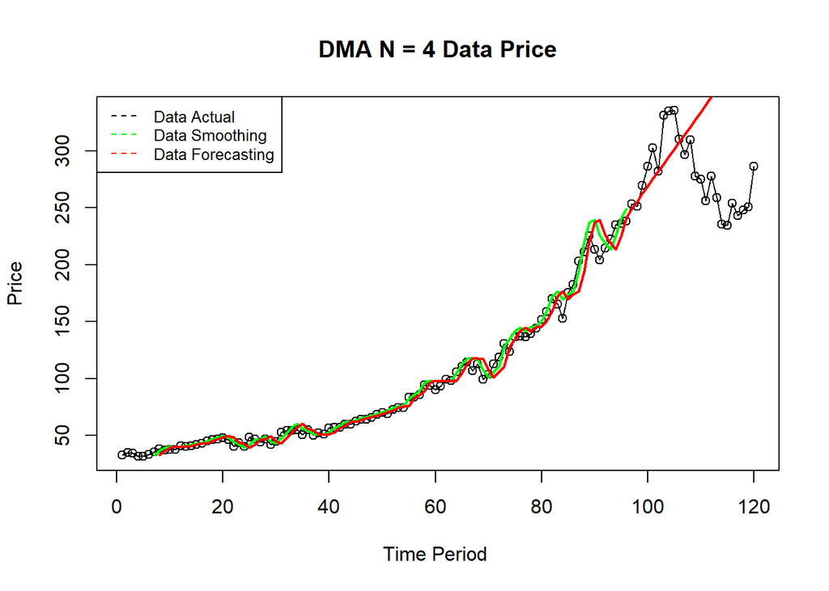

```r
ts.plot(Micros1.ts, xlab = "Time Period ", ylab = "Price", main = "DMA N = 4 Data Price")
points(Micros1.ts)
lines(data.gab2[,3], col = "green", lwd = 2)
lines(data.gab2[,6], col = "red", lwd = 2)
legend("topleft", c("Data Actual", "Data Smoothing", "Data Forecasting"), lty = 8, col = c("black","green","red"), cex = 0.8)
```

Selanjutnya perhitungan akurasi dilakukan baik pada “Data Latih” maupun “Data Uji”. Perhitungan akurasi dilakukan dengan ukuran akurasi SSE, MSE dan MAPE.

```r
# Menghitung Nilai Keakuratan Data Latih
error_train.dma = train_ma.ts-data.ramal2[1:length(train_ma.ts)]
error_train.dma
```

```
## Time Series:
## Start = 1
## End = 96
## Frequency = 1
##  [1]           NA           NA           NA           NA           NA
##  [6]           NA           NA   5.04500000   0.72250000  -1.47708333
## [11]  -2.45916667   1.17395833  -0.18229167  -0.08750000  -0.12895833
## [16]  -0.04104167   2.06604167   0.94604167  -0.26083333  -0.79083333
## [21]  -3.01895833  -8.21625000  -0.80270833  -2.03854167   9.23750000
## [26]   4.95208333  -2.18104167   0.01020833  -7.43229167   0.17416667
## [31]   9.65270833   6.24958333   1.94583333  -2.92125000  -9.61583333
## [36]  -1.38354167  -4.66854167   1.12750000   0.61083333   5.35333333
## [41]   4.20395833   0.58479167   1.25750000  -2.16562500   0.70875000
## [46]   0.83166667  -1.41916667  -0.38750000   1.03562500   1.03354167
## [51]  -1.54333333   1.12145833   0.39854167  -1.07979167   7.30500000
## [56]   1.00625000   0.21854167   5.50895833  -2.80791667  -7.75229167
## [61]  -4.52145833   1.44729167   0.26875000   7.80770833   5.50854167
## [66]   2.00270833 -10.51270833  -4.52729167 -17.51666667  -3.66062500
## [71]  12.10125000  13.28250000  19.80416667  -4.21666667   1.72916667
## [76]  -5.31708333  -8.06958333  -1.99583333  -1.30250000   6.11604167
## [81]   7.83041667  10.99416667  -6.78708333 -23.88041667   5.95750000
## [86]   8.64562500  26.52333333  16.78229167   4.82979167 -23.85416667
## [91] -35.24895833 -11.17791667   3.68208333  21.54354167  10.37125000
## [96]  -2.59145833
```

```r
SSE_train.dma = sum(error_train.dma[8:length(train_ma.ts)]^2)
SSE_train.dma
```

```
## [1] 6658.461
```

```r
MSE_train.dma = mean(error_train.dma[8:length(train_ma.ts)]^2)
MSE_train.dma
```

```
## [1] 74.81417
```

```r
MAPE_train.dma = mean(abs((error_train.dma[8:length(train_ma.ts)]/train_ma.ts[8:length(train_ma.ts)])*100))
MAPE_train.dma
```

```
## [1] 5.482003
```

```r
akurasi_train.dma <- matrix(c(SSE_train.dma, MSE_train.dma, MAPE_train.dma))
akurasi_train.dma
```

```
##             [,1]
## [1,] 6658.460931
## [2,]   74.814168
## [3,]    5.482003
```

```r
row.names(akurasi_train.dma) <- c("SSE", "MSE", "MAPE")
row.names(akurasi_train.dma)
```

```
## [1] "SSE"  "MSE"  "MAPE"
```

```r
colnames(akurasi_train.dma) <- c("Akurasi m = 4")
colnames(akurasi_train.dma)
```

```
## [1] "Akurasi m = 4"
```

```r
akurasi_train.dma
```

```
##      Akurasi m = 4
## SSE    6658.460931
## MSE      74.814168
## MAPE      5.482003
```

Perhitungan akurasi pada “Data Latih” menggunakan nilai MAPE menghasilkan nilai MAPE yang kurang dari 10%, sehingga dikategorikan sangat baik. Selanjutnya, perhitungan nilai akurasi dilakukan pada data uji.

```r
# Menghitung Nilai Keakuratan Data Uji
error_test.dma = test_ma.ts-data.gab2[97:120,6]
error_test.dma
```

```
## Time Series:
## Start = 1
## End = 24
## Frequency = 1
##  [1]    4.090208   -4.607708    7.244375   17.466458   27.448542    0.170625
##  [7]   42.882708   40.124792   33.816875    2.348958  -18.188958  -11.746875
## [13]  -49.934792  -58.972708  -84.310625  -69.408542  -94.886458 -124.874375
## [19] -132.212292 -119.470208 -136.788125 -138.396042 -142.163958 -112.931875
```

```r
SSE_test.dma = sum(error_test.dma^2)
SSE_test.dma
```

```
## [1] 151291.8
```

```r
MSE_test.dma = mean(error_test.dma^2)
MSE_test.dma
```

```
## [1] 6303.827
```

```r
MAPE_test.dma = mean(abs((error_test.dma/test_ma.ts*100)))
MAPE_test.dma
```

```
## [1] 23.56772
```

```r
akurasi_test.dma <- matrix(c(SSE_test.dma, MSE_test.dma, MAPE_test.dma))
akurasi_test.dma
```

```
##              [,1]
## [1,] 151291.83804
## [2,]   6303.82659
## [3,]     23.56772
```

```r
row.names(akurasi_test.dma) <- c("SSE", "MSE", "MAPE")
row.names(akurasi_test.dma)
```

```
## [1] "SSE"  "MSE"  "MAPE"
```

```r
colnames(akurasi_test.dma) <- c("Akurasi m = 4")
colnames(akurasi_test.dma)
```

```
## [1] "Akurasi m = 4"
```

```r
akurasi_test.dma
```

```
##      Akurasi m = 4
## SSE   151291.83804
## MSE     6303.82659
## MAPE      23.56772
```

Perhitungan akurasi menggunakan “Data Latih” menghasilkan nilai MAPE yang kurang dari 10%, sehingga nilai akurasi ini dapat dikategorikan sebagai SANGAT BAIK.

## Single Exponential Smoothing (SES) & Double Exponential Smoothing (DES)

- Metode pemulusan dengan melakukan pembobotan menurun secara eksponensial.
- Nilai yang lebih baru diberi bobot yang lebih besar dari nilai terdahulu.
- Terdapat satu atau lebih parameter pemulusan yang ditentukan secara eksplisit, dan hasil pemilihan parameter tersebut akan menentukan bobot yang akan diberikan pada nilai pengamatan.
- Ada dua macam model, yaitu model tunggal dan ganda.

# Pembagian Data

Pembagian “Data Latih” dan “Data Uji” dilakukan dengan perbandingan 80% “Data Latih” dan 20% “Data Uji”.

```r
# Membagi Training dan Testing
training <- Micros[1:96,]
training
```

```
##         Date  Price no
## 1   5/1/2013  32.93  1
## 2   6/1/2013  34.92  2
## 3   7/1/2013  34.75  3
## 4   8/1/2013  32.06  4
## 5   9/1/2013  31.75  5
## 6  10/1/2013  33.35  6
## 7  11/1/2013  35.67  7
## 8  12/1/2013  38.09  8
## 9   1/1/2014  37.35  9
## 10  2/1/2014  37.74 10
## 11  3/1/2014  37.92 11
## 12  4/1/2014  41.15 12
## 13  5/1/2014  40.24 13
## 14  6/1/2014  40.95 14
```

[output cut: 82 more lines]

```r
testing <- Micros[97:120,]
testing
```

```
##          Date  Price  no
## 97   5/1/2021 253.40  97
## 98   6/1/2021 251.23  98
## 99   7/1/2021 269.61  99
## 100  8/1/2021 286.36 100
## 101  9/1/2021 302.87 101
## 102 10/1/2021 282.12 102
## 103 11/1/2021 331.36 103
## 104 12/1/2021 335.13 104
## 105  1/1/2022 335.35 105
## 106  2/1/2022 310.41 106
## 107  3/1/2022 296.40 107
## 108  4/1/2022 309.37 108
## 109  5/1/2022 277.71 109
## 110  6/1/2022 275.20 110
## 111  7/1/2022 256.39 111
## 112  8/1/2022 277.82 112
## 113  9/1/2022 258.87 113
## 114 10/1/2022 235.41 114
## 115 11/1/2022 234.60 115
## 116 12/1/2022 253.87 116
## 117  1/1/2023 243.08 117
## 118  2/1/2023 248.00 118
## 119  3/1/2023 250.76 119
## 120  4/1/2023 286.52 120
```

```r
train.ts <- ts(training$Price)
train.ts
```

```
## Time Series:
## Start = 1
## End = 96
## Frequency = 1
##  [1]  32.93  34.92  34.75  32.06  31.75  33.35  35.67  38.09  37.35  37.74
## [11]  37.92  41.15  40.24  40.95  41.86  43.21  45.43  46.27  46.89  47.88
## [21]  46.66  40.59  43.67  40.60  48.58  47.06  44.46  46.98  42.17  44.75
## [31]  52.85  54.41  54.32  54.88  50.97  55.05  50.00  52.44  51.13  56.60
## [41]  57.01  57.41  59.97  60.11  62.79  64.36  64.13  65.81  68.68  70.24
## [51]  69.33  73.10  74.71  74.71  83.68  83.60  86.13  94.79  93.99  90.47
## [61]  93.21  99.28  98.10 106.03 110.85 114.75 107.05 113.00  99.55 103.78
## [71] 112.89 118.95 130.53 123.85 136.63 137.00 136.61 139.66 144.26 151.81
## [81] 158.78 170.43 165.31 153.00 175.80 182.54 203.14 211.52 225.51 213.49
## [91] 204.29 214.51 222.53 235.06 235.90 238.47
```

```r
test.ts <- ts(testing$Price)
test.ts
```

```
## Time Series:
## Start = 1
## End = 24
## Frequency = 1
##  [1] 253.40 251.23 269.61 286.36 302.87 282.12 331.36 335.13 335.35 310.41
## [11] 296.40 309.37 277.71 275.20 256.39 277.82 258.87 235.41 234.60 253.87
## [21] 243.08 248.00 250.76 286.52
```

# Eksplorasi Data

Eksplorasi dilakukan dengan membuat “Plot Data Deret Waktu” untuk keseluruhan data, yakni “Data Latih” dan “Data Uji”.

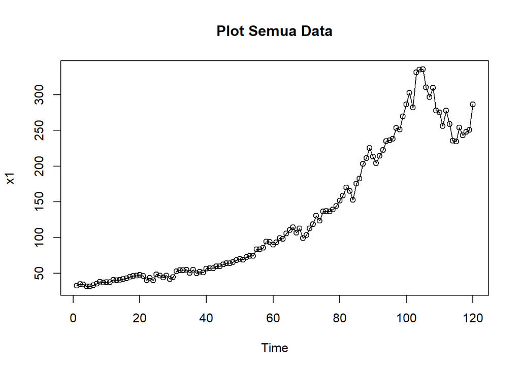

```r
# Eksplorasi Data
plot(Micros1.ts, col = "black", main = "Plot Semua Data")
points(Micros1.ts)
```

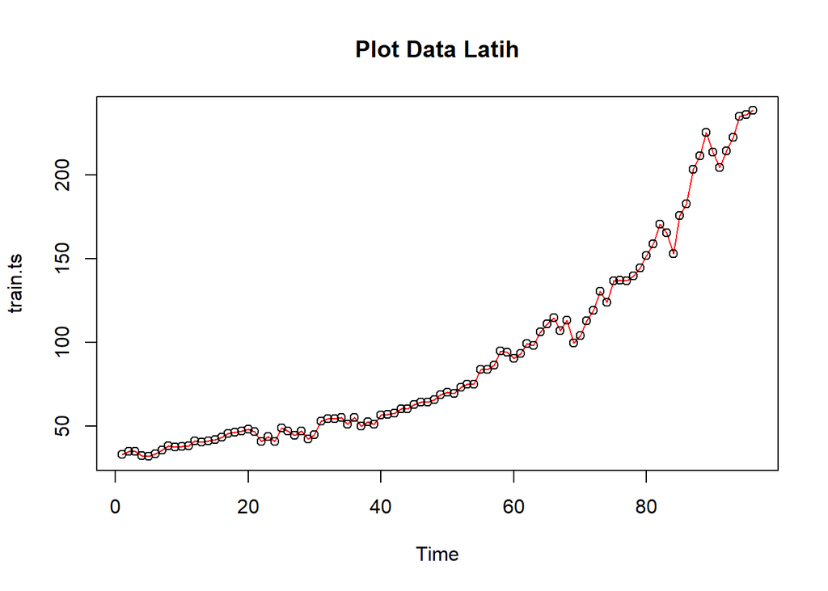

```r
plot(train.ts, col = "red", main = "Plot Data Latih")
points(train.ts)
```

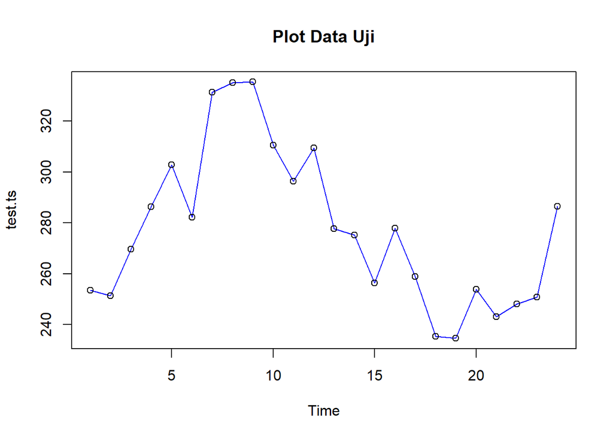

```r
plot(test.ts, col = "blue", main = "Plot Data Uji")
points(test.ts)
```

Eksplorasi data juga dapat dilakukan menggunakan package `GGPLOT2`.

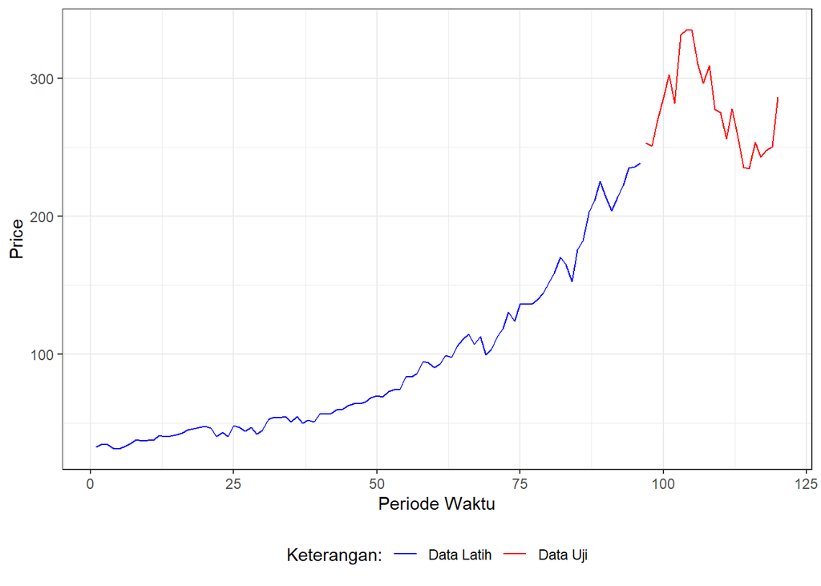

```r
# Eksplorasi dengan GGPLOT
library(ggplot2)
ggplot() +
  geom_line(data = training, aes(x = no, y = Price, col = "Data Latih")) +
  geom_line(data = testing, aes(x = no, y = Price, col = "Data Uji")) +
  labs(x = "Periode Waktu", y = "Price", color = "Legend") +
  scale_colour_manual(name="Keterangan:", breaks = c("Data Latih", "Data Uji"),
                      values = c("blue", "red")) +
  theme_bw() + theme(legend.position = "bottom",
                     plot.caption = element_text(hjust = 0.5, size = 12))
```

## Single Exponential Smoothing (SES)

Pemulusan dengan metode SES dapat dilakukan dengan dua fungsi dari *packages* berbeda, yaitu: (1) fungsi `ses()` dari *packages* `forecast` (2) fungsi `HoltWinters` dari *packages* `stats`

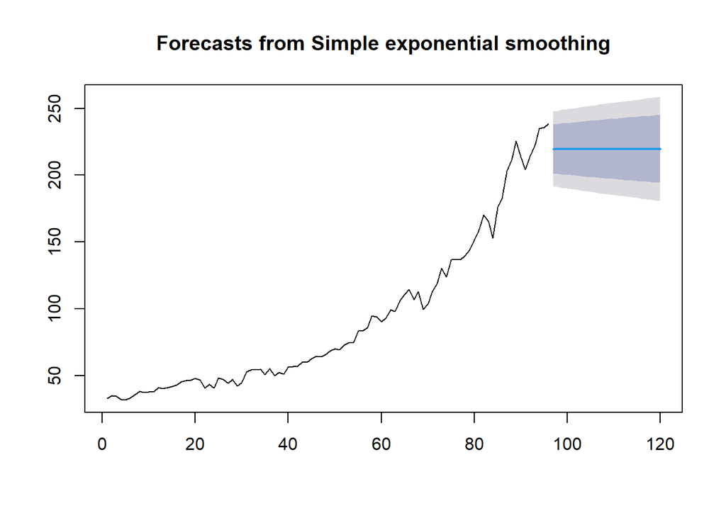

```r
# Cara 1 (Fungsi SES)
ses.1 <- ses(train.ts, h = 24, alpha = 0.2)
plot(ses.1)
```

```r
ses.1
```

```
##     Point Forecast    Lo 80    Hi 80    Lo 95    Hi 95
##  97        219.769 201.4577 238.0803 191.7643 247.7737
##  98        219.769 201.0951 238.4429 191.2097 248.3283
##  99        219.769 200.7394 238.7986 190.6657 248.8723
## 100        219.769 200.3902 239.1478 190.1316 249.4064
## 101        219.769 200.0472 239.4908 189.6070 249.9310
## 102        219.769 199.7100 239.8280 189.0914 250.4466
## 103        219.769 199.3784 240.1596 188.5843 250.9537
## 104        219.769 199.0522 240.4858 188.0853 251.4527
## 105        219.769 198.7309 240.8070 187.5941 251.9439
## 106        219.769 198.4146 241.1234 187.1102 252.4278
## 107        219.769 198.1028 241.4352 186.6334 252.9046
## 108        219.769 197.7955 241.7425 186.1634 253.3746
## 109        219.769 197.4924 242.0456 185.6998 253.8382
## 110        219.769 197.1933 242.3446 185.2425 254.2955
## 111        219.769 196.8982 242.6398 184.7912 254.7468
## 112        219.769 196.6069 242.9311 184.3456 255.1924
## 113        219.769 196.3191 243.2189 183.9055 255.6325
## 114        219.769 196.0349 243.5031 183.4708 256.0672
## 115        219.769 195.7540 243.7840 183.0412 256.4968
## 116        219.769 195.4763 244.0616 182.6166 256.9214
## 117        219.769 195.2018 244.3361 182.1968 257.3412
## 118        219.769 194.9304 244.6076 181.7816 257.7564
## 119        219.769 194.6618 244.8761 181.3709 258.1671
## 120        219.769 194.3962 245.1418 180.9646 258.5734
```

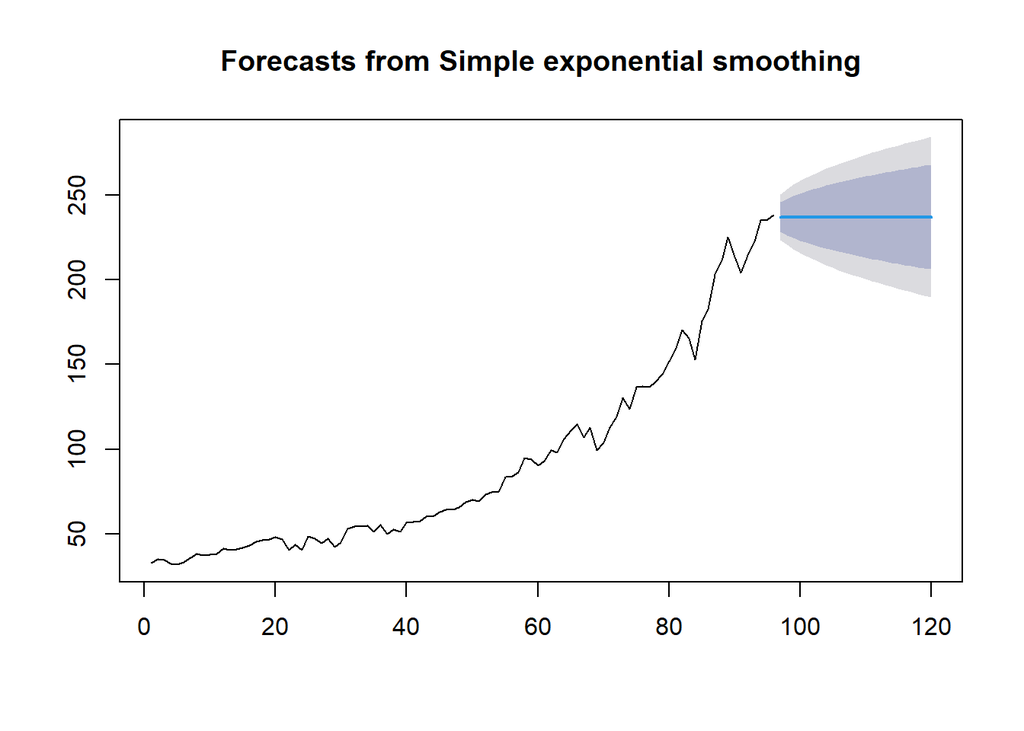

```r
ses.2 <- ses(train.ts, h = 24, alpha = 0.7)
plot(ses.2)
```

```r
ses.2
```

```
##     Point Forecast    Lo 80    Hi 80    Lo 95    Hi 95
##  97       237.2034 228.3619 246.0449 223.6815 250.7253
##  98       237.2034 226.4110 247.9958 220.6979 253.7089
##  99       237.2034 224.7624 249.6444 218.1765 256.2303
## 100       237.2034 223.3079 251.0989 215.9521 258.4547
## 101       237.2034 221.9920 252.4148 213.9395 260.4673
## 102       237.2034 220.7811 253.6257 212.0877 262.3191
## 103       237.2034 219.6536 254.7532 210.3633 264.0435
## 104       237.2034 218.5943 255.8125 208.7432 265.6636
## 105       237.2034 217.5921 256.8147 207.2105 267.1963
## 106       237.2034 216.6387 257.7681 205.7524 268.6544
## 107       237.2034 215.7276 258.6793 204.3589 270.0479
## 108       237.2034 214.8535 259.5533 203.0222 271.3846
## 109       237.2034 214.0125 260.3944 201.7359 272.6709
## 110       237.2034 213.2008 261.2060 200.4946 273.9122
## 111       237.2034 212.4157 261.9911 199.2939 275.1129
## 112       237.2034 211.6548 262.7520 198.1301 276.2767
## 113       237.2034 210.9158 263.4910 197.0000 277.4068
## 114       237.2034 210.1971 264.2097 195.9008 278.5060
## 115       237.2034 209.4970 264.9098 194.8301 279.5767
## 116       237.2034 208.8142 265.5926 193.7858 280.6210
## 117       237.2034 208.1474 266.2594 192.7660 281.6408
## 118       237.2034 207.4955 266.9113 191.7692 282.6376
## 119       237.2034 206.8577 267.5491 190.7937 283.6131
## 120       237.2034 206.2330 268.1738 189.8383 284.5685
```

Untuk mendapatkan gambar hasil pemulusan pada “Data Latih” dengan fungsi `ses()` , perlu digunakan fungsi `autoplot()` dan `autolayer()` dari *library packages* `GGPLOT2` .

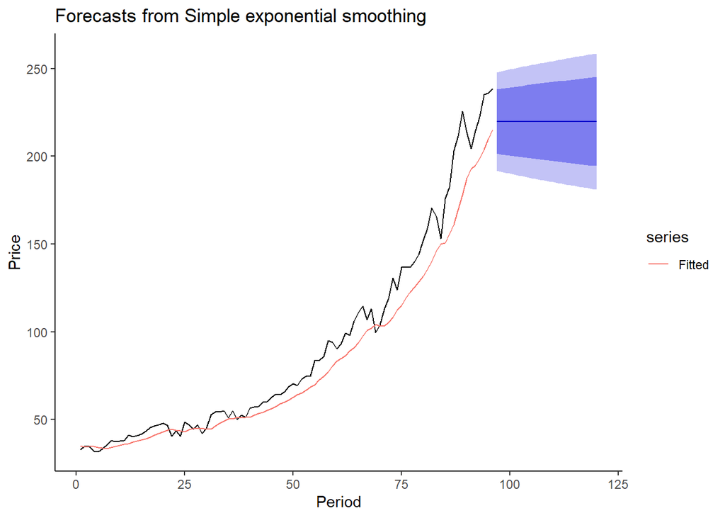

```r
library(ggplot2)
autoplot(ses.1) +
  autolayer(fitted(ses.1), series = "Fitted") + ylab("Price") + xlab("Period") + theme_classic()
```

Pada fungsi `ses()` , terdapat beberapa argumen yang umum digunakan, yaitu nilai `y` , `gamma` , `beta` , `alpha` , dan `h` .

Nilai `y` adalah nilai data deret waktu, `gamma` adalah parameter pemulusan untuk komponen musiman, `beta` adalah parameter pemulusan untuk tren, dan `alpha` adalah parameter pemulusan untuk stasioner, serta `h` adalah banyaknya periode yang akan diramalkan.

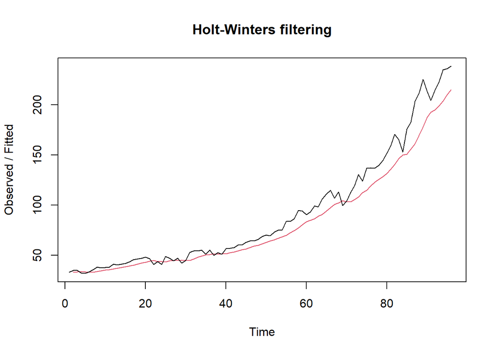

```r
# Cara 2 (Fungsi Holtwinter)
ses1 <- HoltWinters(train.ts, gamma = FALSE, beta = FALSE, alpha = 0.2)
plot(ses1)
```

# Peramalan 1

```r
ramalan1 <- forecast(ses1, h = 24)
ramalan1
```

```
##     Point Forecast    Lo 80    Hi 80    Lo 95    Hi 95
##  97        219.769 206.5407 232.9972 199.5381 239.9999
##  98        219.769 206.2788 233.2592 199.1375 240.4005
##  99        219.769 206.0218 233.5162 198.7445 240.7935
## 100        219.769 205.7695 233.7685 198.3587 241.1793
## 101        219.769 205.5217 234.0163 197.9797 241.5583
## 102        219.769 205.2782 234.2598 197.6072 241.9308
## 103        219.769 205.0386 234.4993 197.2409 242.2971
## 104        219.769 204.8029 234.7350 196.8804 242.6576
## 105        219.769 204.5709 234.9671 196.5255 243.0125
## 106        219.769 204.3423 235.1956 196.1760 243.3620
## 107        219.769 204.1171 235.4209 195.8315 243.7065
## 108        219.769 203.8951 235.6429 195.4920 244.0460
## 109        219.769 203.6761 235.8619 195.1571 244.3809
## 110        219.769 203.4601 236.0779 194.8267 244.7113
## 111        219.769 203.2469 236.2911 194.5007 245.0373
## 112        219.769 203.0364 236.5016 194.1788 245.3592
## 113        219.769 202.8286 236.7094 193.8609 245.6771
## 114        219.769 202.6232 236.9148 193.5468 245.9912
## 115        219.769 202.4203 237.1177 193.2365 246.3015
## 116        219.769 202.2197 237.3182 192.9297 246.6083
## 117        219.769 202.0214 237.5166 192.6265 246.9115
## 118        219.769 201.8253 237.7127 192.3265 247.2115
## 119        219.769 201.6313 237.9067 192.0298 247.5081
## 120        219.769 201.4394 238.0986 191.7363 247.8017
```

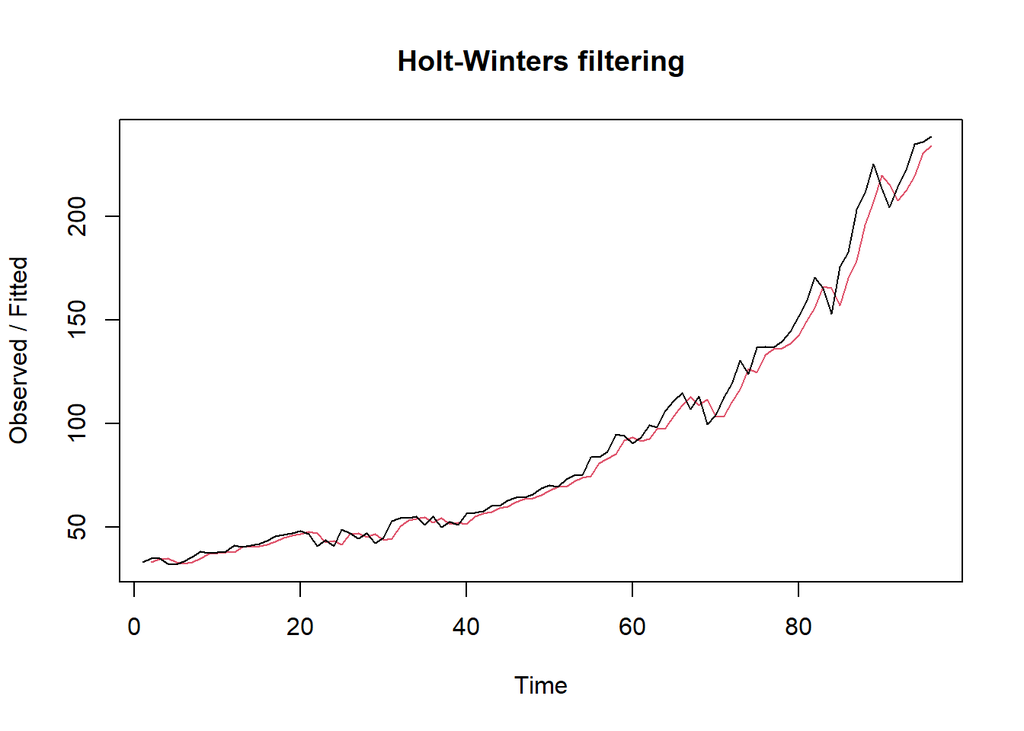

```r
ses2 <- HoltWinters(train.ts, gamma = FALSE, beta = FALSE, alpha = 0.7)
plot(ses2)
```

# Peramalan 2

```r
ramalan2 <- forecast(ses2, h = 24)
ramalan2
```

```
##     Point Forecast    Lo 80    Hi 80    Lo 95    Hi 95
##  97       237.2034 229.2968 245.1100 225.1113 249.2955
##  98       237.2034 227.5522 246.8547 222.4431 251.9637
##  99       237.2034 226.0778 248.3290 220.1883 254.2185
## 100       237.2034 224.7772 249.6296 218.1991 256.2077
## 101       237.2034 223.6003 250.8065 216.3993 258.0075
## 102       237.2034 222.5175 251.8893 214.7433 259.6635
## 103       237.2034 221.5092 252.8976 213.2012 261.2056
## 104       237.2034 220.5619 253.8449 211.7524 262.6544
## 105       237.2034 219.6657 254.7411 210.3818 264.0250
## 106       237.2034 218.8131 255.5937 209.0778 265.3290
## 107       237.2034 217.9983 256.4085 207.8317 266.5751
## 108       237.2034 217.2167 257.1901 206.6364 267.7704
## 109       237.2034 216.4645 257.9423 205.4861 268.9207
## 110       237.2034 215.7387 258.6681 204.3760 270.0308
## 111       237.2034 215.0367 259.3701 203.3023 271.1045
## 112       237.2034 214.3562 260.0506 202.2616 272.1452
## 113       237.2034 213.6953 260.7115 201.2509 273.1559
## 114       237.2034 213.0526 261.3542 200.2680 274.1389
## 115       237.2034 212.4265 261.9803 199.3105 275.0963
## 116       237.2034 211.8159 262.5909 198.3766 276.0302
## 117       237.2034 211.2196 263.1872 197.4646 276.9422
## 118       237.2034 210.6367 263.7701 196.5732 277.8337
## 119       237.2034 210.0663 264.3405 195.7008 278.7060
## 120       237.2034 209.5077 264.8991 194.8464 279.5604
```

Fungsi `HoltWinters` memiliki argumen yang sama dengan fungsi `ses()` . Argumen-argumen kedua fungsi dapat dilihat lebih lanjut dengan `?ses()` atau `?HoltWinters` .

Nilai parameter $\alpha$ dari kedua fungsi dapat dioptimalkan menyesuaikan dari *error*-nya paling minimumnya. Caranya adalah dengan membuat parameter $\alpha =$ `NULL` .

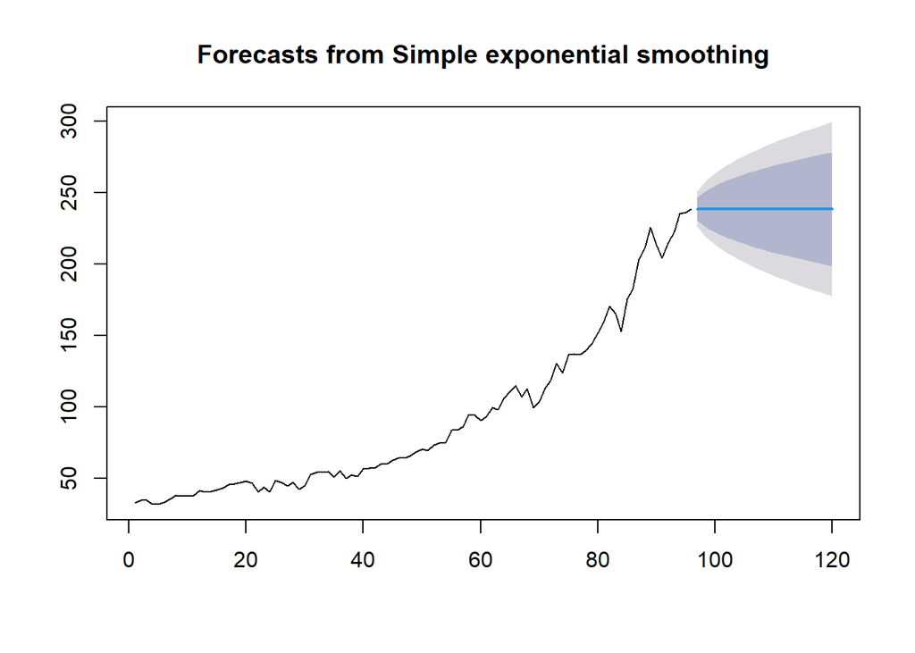

```r
# SES
ses.opt <- ses(train.ts, h = 24, alpha = NULL)
plot(ses.opt)
```

```r
ses.opt
```

```
##     Point Forecast    Lo 80    Hi 80    Lo 95    Hi 95
##  97       238.4697 230.3544 246.5851 226.0584 250.8811
##  98       238.4697 226.9935 249.9460 220.9183 256.0212
##  99       238.4697 224.4145 252.5250 216.9741 259.9654
## 100       238.4697 222.2403 254.6992 213.6489 263.2906
## 101       238.4697 220.3247 256.6148 210.7193 266.2202
## 102       238.4697 218.5929 258.3466 208.0708 268.8687
## 103       238.4697 217.0004 259.9391 205.6352 271.3043
## 104       238.4697 215.5181 261.4214 203.3682 273.5713
## 105       238.4697 214.1259 262.8136 201.2390 275.7005
## 106       238.4697 212.8091 264.1304 199.2251 277.7144
## 107       238.4697 211.5566 265.3829 197.3097 279.6298
## 108       238.4697 210.3599 266.5796 195.4795 281.4600
## 109       238.4697 209.2121 267.7274 193.7241 283.2154
## 110       238.4697 208.1077 268.8318 192.0350 284.9045
## 111       238.4697 207.0421 269.8974 190.4053 286.5342
## 112       238.4697 206.0114 270.9281 188.8290 288.1105
## 113       238.4697 205.0124 271.9270 187.3012 289.6383
## 114       238.4697 204.0425 272.8970 185.8178 291.1217
## 115       238.4697 203.0991 273.8404 184.3750 292.5645
## 116       238.4697 202.1802 274.7592 182.9697 293.9697
## 117       238.4697 201.2841 275.6554 181.5992 295.3403
## 118       238.4697 200.4090 276.5305 180.2609 296.6786
## 119       238.4697 199.5536 277.3859 178.9527 297.9868
## 120       238.4697 198.7166 278.2229 177.6726 299.2669
```

```r
# Lambda Optimum Holt Winter
sesopt <- HoltWinters(train.ts, gamma = FALSE, beta = FALSE, alpha = NULL)
sesopt
```

```
## Holt-Winters exponential smoothing without trend and without seasonal component.
##
## Call:
## HoltWinters(x = train.ts, alpha = NULL, beta = FALSE, gamma = FALSE)
##
## Smoothing parameters:
##  alpha: 0.9999516
##  beta : FALSE
##  gamma: FALSE
##
## Coefficients:
##       [,1]
## a 238.4699
```

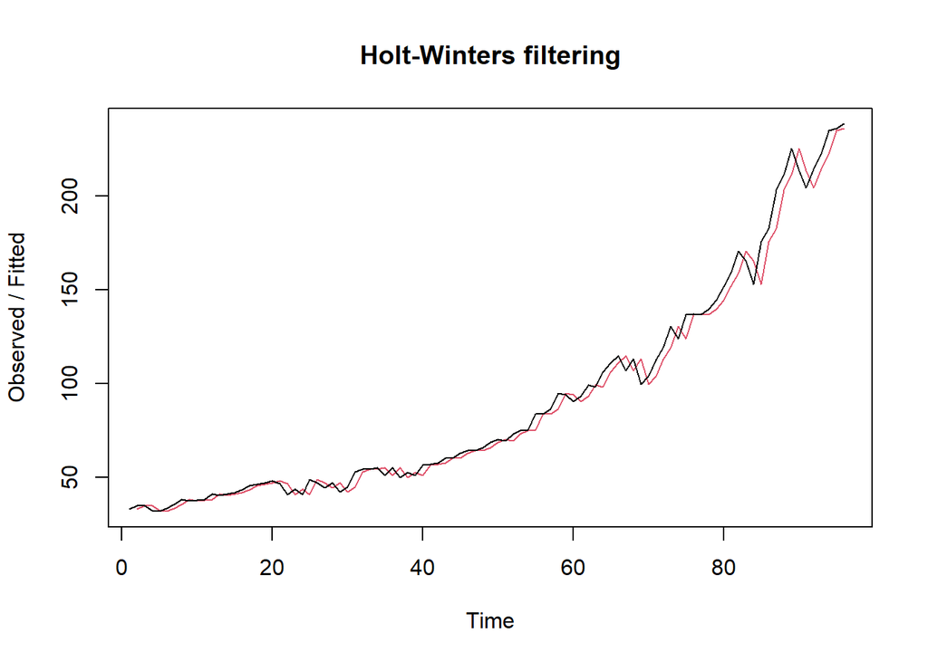

```r
plot(sesopt)
```

# Peramalan Optimum

```r
ramalanopt <- forecast(sesopt, h = 24)
ramalanopt
```

```
##     Point Forecast    Lo 80    Hi 80    Lo 95    Hi 95
##  97       238.4699 230.8483 246.0914 226.8137 250.1260
##  98       238.4699 227.6917 249.2481 221.9860 254.9537
##  99       238.4699 225.2694 251.6703 218.2815 258.6582
## 100       238.4699 223.2274 253.7124 215.1585 261.7813
## 101       238.4699 221.4283 255.5115 212.4070 264.5328
## 102       238.4699 219.8018 257.1380 209.9195 267.0203
## 103       238.4699 218.3060 258.6337 207.6319 269.3078
## 104       238.4699 216.9138 260.0259 205.5028 271.4370
## 105       238.4699 215.6063 261.3335 203.5030 273.4368
## 106       238.4699 214.3695 262.5702 201.6116 275.3282
## 107       238.4699 213.1932 263.7465 199.8126 277.1272
## 108       238.4699 212.0693 264.8705 198.0936 278.8461
## 109       238.4699 210.9913 265.9485 196.4450 280.4948
## 110       238.4699 209.9540 266.9858 194.8586 282.0812
## 111       238.4699 208.9531 267.9866 193.3279 283.6118
## 112       238.4699 207.9851 268.9546 191.8475 285.0923
## 113       238.4699 207.0469 269.8928 190.4126 286.5271
## 114       238.4699 206.1359 270.8038 189.0194 287.9204
## 115       238.4699 205.2499 271.6898 187.6643 289.2754
## 116       238.4699 204.3869 272.5528 186.3445 290.5953
## 117       238.4699 203.5452 273.3945 185.0572 291.8825
## 118       238.4699 202.7234 274.2164 183.8003 293.1394
## 119       238.4699 201.9200 275.0198 182.5716 294.3681
## 120       238.4699 201.1339 275.8059 181.3694 295.5704
```

Setelah dilakukan peramalan, akan dilakukan perhitungan keakuratan hasil peramalan. Perhitungan akurasi ini dilakukan baik pada “Data Latih” dan “Data Uji”.

## Akurasi Data Latih

Perhitungan akurasi data dapat dilakukan dengan cara langsung maupun manual. Secara langsung, nilai akurasi dapat diambil dari objek yang tersimpan pada hasil SES, yaitu *sum of squared errors* (SSE). Nilai akurasi lain dapat dihitung pula dari nilai SSE tersebut.

# Keakuratan Metode

```r
# Pada Data Latih
SSE1 <- ses1$SSE
SSE1
```

```
## [1] 19201.74
```

```r
MSE1 <- ses1$SSE/length(train.ts)
MSE1
```

```
## [1] 200.0182
```

```r
RMSE1 <- sqrt(MSE1)
RMSE1
```

```
## [1] 14.14278
```

```r
akurasi1 <- matrix(c(SSE1, MSE1, RMSE1))
akurasi1
```

```
##             [,1]
## [1,] 19201.74384
## [2,]   200.01816
## [3,]    14.14278
```

```r
row.names(akurasi1) <- c("SSE", "MSE", "RMSE")
row.names(akurasi1)
```

```
## [1] "SSE"  "MSE"  "RMSE"
```

```r
colnames(akurasi1) <- c("Akurasi lambda = 0.2")
colnames(akurasi1)
```

```
## [1] "Akurasi lambda = 0.2"
```

```r
akurasi1
```

```
##      Akurasi lambda = 0.2
## SSE           19201.74384
## MSE             200.01816
## RMSE             14.14278
```

```r
SSE2 <- ses2$SSE
SSE2
```

```
## [1] 4474.375
```

```r
MSE2 <- ses2$SSE/length(train.ts)
MSE2
```

```
## [1] 46.60807
```

```r
RMSE2 <- sqrt(MSE2)
RMSE2
```

```
## [1] 6.82701
```

```r
akurasi2 <- matrix(c(SSE2, MSE2, RMSE2))
akurasi2
```

```
##            [,1]
## [1,] 4474.37490
## [2,]   46.60807
## [3,]    6.82701
```

```r
row.names(akurasi2) <- c("SSE", "MSE", "RMSE")
row.names(akurasi2)
```

```
## [1] "SSE"  "MSE"  "RMSE"
```

```r
colnames(akurasi2) <- c("Akurasi lambda = 0.7")
colnames(akurasi2)
```

```
## [1] "Akurasi lambda = 0.7"
```

```r
akurasi2
```

```
##      Akurasi lambda = 0.7
## SSE            4474.37490
## MSE              46.60807
## RMSE              6.82701
```

# Cara Manual 1

```r
fitted1 <- ramalan1$fitted
fitted1
```

```
## Time Series:
## Start = 1
## End = 96
## Frequency = 1
##  [1]        NA  32.93000  33.32800  33.61240  33.30192  32.99154  33.06323
##  [8]  33.58458  34.48567  35.05853  35.59483  36.05986  37.07789  37.71031
## [15]  38.35825  39.05860  39.88888  40.99710  42.05168  43.01935  43.99148
## [22]  44.52518  43.73815  43.72452  43.09961  44.19569  44.76855  44.70684
## [29]  45.16147  44.56318  44.60054  46.25043  47.88235  49.16988  50.31190
## [36]  50.44352  51.36482  51.09185  51.36148  51.31519  52.37215  53.29972
## [43]  54.12178  55.29142  56.25514  57.56211  58.92169  59.96335  61.13268
## [50]  62.64214  64.16172  65.19537  66.77630  68.36304  69.63243  72.44194
## [57]  74.67356  76.96484  80.52988  83.22190  84.67152  86.37922  88.95937
## [64]  90.78750  93.83600  97.23880 100.74104 102.00283 104.20227 103.27181
## [71] 103.37345 105.27676 108.01141 112.51513 114.78210 119.15168 122.72134
## [78] 125.49908 128.33126 131.51701 135.57561 140.21649 146.25919 150.06935
## [85] 150.65548 155.68438 161.05551 169.47241 177.88192 187.40754 192.62403
## [92] 194.95723 198.86778 203.60022 209.89218 215.09374
```

```r
sisaan1 <- ramalan1$residuals
sisaan1
```

```
## Time Series:
## Start = 1
## End = 96
## Frequency = 1
##  [1]          NA  1.99000000  1.42200000 -1.55240000 -1.55192000  0.35846400
##  [7]  2.60677120  4.50541696  2.86433357  2.68146685  2.32517348  5.09013879
## [13]  3.16211103  3.23968882  3.50175106  4.15140085  5.54112068  5.27289654
## [19]  4.83831723  4.86065379  2.66852303 -3.93518158 -0.06814526 -3.12451621
## [25]  5.48038703  2.86430963 -0.30855230  2.27315816 -2.99147347  0.18682122
## [31]  8.24945698  8.15956558  6.43765247  5.71012197  0.65809758  4.60647806
## [37] -1.36481755  1.34814596 -0.23148323  5.28481341  4.63785073  4.11028059
## [43]  5.84822447  4.81857957  6.53486366  6.79789093  5.20831274  5.84665019
## [49]  7.54732015  7.59785612  5.16828490  7.90462792  7.93370234  6.34696187
## [55] 14.04756949 11.15805560 11.45644448 17.82515558 13.46012447  7.24809957
## [61]  8.53847966 12.90078373  9.14062698 15.24250158 17.01400127 17.51120101
## [67]  6.30896081 10.99716865 -4.65226508  0.50818794  9.51655035 13.67324028
## [73] 22.51859222 11.33487378 21.84789902 17.84831922 13.88865537 14.16092430
## [79] 15.92873944 20.29299155 23.20439324 30.21351459 19.05081167  2.93064934
## [85] 25.14451947 26.85561558 42.08449246 42.04759397 47.62807518 26.08246014
## [91] 11.66596811 19.55277449 23.66221959 31.45977567 26.00782054 23.37625643
```

```r
head(sisaan1)
```

```
## Time Series:
## Start = 1
## End = 6
## Frequency = 1
## [1]        NA  1.990000  1.422000 -1.552400 -1.551920  0.358464
```

```r
resid1 <- training$Price-ramalan1$fitted
resid1
```

```
## Time Series:
## Start = 1
## End = 96
## Frequency = 1
##  [1]          NA  1.99000000  1.42200000 -1.55240000 -1.55192000  0.35846400
##  [7]  2.60677120  4.50541696  2.86433357  2.68146685  2.32517348  5.09013879
## [13]  3.16211103  3.23968882  3.50175106  4.15140085  5.54112068  5.27289654
## [19]  4.83831723  4.86065379  2.66852303 -3.93518158 -0.06814526 -3.12451621
## [25]  5.48038703  2.86430963 -0.30855230  2.27315816 -2.99147347  0.18682122
## [31]  8.24945698  8.15956558  6.43765247  5.71012197  0.65809758  4.60647806
## [37] -1.36481755  1.34814596 -0.23148323  5.28481341  4.63785073  4.11028059
## [43]  5.84822447  4.81857957  6.53486366  6.79789093  5.20831274  5.84665019
## [49]  7.54732015  7.59785612  5.16828490  7.90462792  7.93370234  6.34696187
## [55] 14.04756949 11.15805560 11.45644448 17.82515558 13.46012447  7.24809957
## [61]  8.53847966 12.90078373  9.14062698 15.24250158 17.01400127 17.51120101
## [67]  6.30896081 10.99716865 -4.65226508  0.50818794  9.51655035 13.67324028
## [73] 22.51859222 11.33487378 21.84789902 17.84831922 13.88865537 14.16092430
## [79] 15.92873944 20.29299155 23.20439324 30.21351459 19.05081167  2.93064934
## [85] 25.14451947 26.85561558 42.08449246 42.04759397 47.62807518 26.08246014
## [91] 11.66596811 19.55277449 23.66221959 31.45977567 26.00782054 23.37625643
```

```r
head(resid1)
```

```
## Time Series:
## Start = 1
## End = 6
## Frequency = 1
## [1]        NA  1.990000  1.422000 -1.552400 -1.551920  0.358464
```

# Cara Manual 2

```r
SSE.1 = sum(sisaan1[2:length(train.ts)]^2)
SSE.1
```

```
## [1] 19201.74
```

```r
MSE.1 = SSE.1/length(train.ts)
MSE.1
```

```
## [1] 200.0182
```

```r
MAPE.1 = sum(abs(sisaan1[2:length(train.ts)]/train.ts[2:length(train.ts)])*
               100)/length(train.ts)
MAPE.1
```

```
## [1] 9.610519
```

```r
akurasi.1 <- matrix(c(SSE.1, MSE.1, MAPE.1))
akurasi.1
```

```
##              [,1]
## [1,] 19201.743838
## [2,]   200.018165
## [3,]     9.610519
```

```r
row.names(akurasi.1) <- c("SSE", "MSE", "MAPE")
row.names(akurasi.1)
```

```
## [1] "SSE"  "MSE"  "MAPE"
```

```r
colnames(akurasi.1) <- c("Akurasi lambda = 0.2")
colnames(akurasi.1)
```

```
## [1] "Akurasi lambda = 0.2"
```

```r
akurasi.1
```

```
##      Akurasi lambda = 0.2
## SSE          19201.743838
## MSE            200.018165
## MAPE             9.610519
```

```r
fitted2 <- ramalan2$fitted
fitted2
```

```
## Time Series:
## Start = 1
## End = 96
## Frequency = 1
##  [1]        NA  32.93000  34.32300  34.62190  32.82857  32.07357  32.96707
##  [8]  34.85912  37.12074  37.28122  37.60237  37.82471  40.15241  40.21372
## [15]  40.72912  41.52074  42.70322  44.61197  45.77259  46.55478  47.48243
## [22]  46.90673  42.48502  43.31451  41.41435  46.43031  46.87109  45.18333
## [29]  46.44100  43.45130  44.36039  50.30312  53.17794  53.97738  54.60921
## [36]  52.06176  54.15353  51.24606  52.08182  51.41555  55.04466  56.42040
## [43]  57.11312  59.11294  59.81088  61.89626  63.62088  63.97726  65.26018
## [50]  67.65405  69.46422  69.37026  71.98108  73.89132  74.46440  80.91532
## [57]  82.79460  85.12938  91.89181  93.36054  91.33716  92.64815  97.29044
## [64]  97.85713 103.57814 108.66844 112.92553 108.81266 111.74380 103.20814
## [71] 103.60844 110.10553 116.29666 126.26000 124.57300 133.01290 135.80387
## [78] 136.36816 138.67245 142.58373 149.04212 155.85864 166.05859 165.53458
## [85] 156.76037 170.08811 178.80443 195.83933 206.81580 219.90174 215.41352
## [92] 207.62706 212.44512 219.50454 230.39336 234.24801
```

```r
sisaan2 <- ramalan2$residuals
sisaan2
```

```
## Time Series:
## Start = 1
## End = 96
## Frequency = 1
##  [1]           NA   1.99000000   0.42700000  -2.56190000  -1.07857000
##  [6]   1.27642900   2.70292870   3.23087861   0.22926358   0.45877907
## [11]   0.31763372   3.32529012   0.08758704   0.73627611   1.13088283
## [16]   1.68926485   2.72677945   1.65803384   1.11741015   1.32522305
## [21]  -0.82243309  -6.31672993   1.18498102  -2.71450569   7.16564829
## [26]   0.62969449  -2.41109165   1.79667250  -4.27099825   1.29870053
## [31]   8.48961016   4.10688305   1.14206491   0.90261947  -3.63921416
## [36]   2.98823575  -4.15352927   1.19394122  -0.95181763   5.18445471
## [41]   1.96533641   0.98960092   2.85688028   0.99706408   2.97911922
## [46]   2.46373577   0.50912073   1.83273622   3.41982087   2.58594626
## [51]  -0.13421612   3.72973516   2.72892055   0.81867616   9.21560285
## [56]   2.68468085   3.33540426   9.66062128   2.09818638  -2.89054409
## [61]   1.87283677   6.63185103   0.80955531   8.17286659   7.27185998
## [66]   6.08155799  -5.87553260   4.18734022 -12.19379793   0.57186062
## [71]   9.28155819   8.84446746  14.23334024  -2.40999793  12.05700062
## [76]   3.98710019   0.80613006   3.29183902   5.58755171   9.22626551
## [81]   9.73787965  14.57136390  -0.74859083 -12.53457725  19.03962683
## [86]  12.45188805  24.33556641  15.68066992  18.69420098  -6.41173971
## [91] -11.12352191   6.88294343  10.08488303  15.55546491   5.50663947
## [96]   4.22199184
```

```r
head(sisaan2)
```

```
## Time Series:
## Start = 1
## End = 6
## Frequency = 1
## [1]        NA  1.990000  0.427000 -2.561900 -1.078570  1.276429
```

```r
resid2 <- training$Price-ramalan2$fitted
resid2
```

```
## Time Series:
## Start = 1
## End = 96
## Frequency = 1
##  [1]           NA   1.99000000   0.42700000  -2.56190000  -1.07857000
##  [6]   1.27642900   2.70292870   3.23087861   0.22926358   0.45877907
## [11]   0.31763372   3.32529012   0.08758704   0.73627611   1.13088283
## [16]   1.68926485   2.72677945   1.65803384   1.11741015   1.32522305
## [21]  -0.82243309  -6.31672993   1.18498102  -2.71450569   7.16564829
## [26]   0.62969449  -2.41109165   1.79667250  -4.27099825   1.29870053
## [31]   8.48961016   4.10688305   1.14206491   0.90261947  -3.63921416
## [36]   2.98823575  -4.15352927   1.19394122  -0.95181763   5.18445471
## [41]   1.96533641   0.98960092   2.85688028   0.99706408   2.97911922
## [46]   2.46373577   0.50912073   1.83273622   3.41982087   2.58594626
## [51]  -0.13421612   3.72973516   2.72892055   0.81867616   9.21560285
## [56]   2.68468085   3.33540426   9.66062128   2.09818638  -2.89054409
## [61]   1.87283677   6.63185103   0.80955531   8.17286659   7.27185998
## [66]   6.08155799  -5.87553260   4.18734022 -12.19379793   0.57186062
## [71]   9.28155819   8.84446746  14.23334024  -2.40999793  12.05700062
## [76]   3.98710019   0.80613006   3.29183902   5.58755171   9.22626551
## [81]   9.73787965  14.57136390  -0.74859083 -12.53457725  19.03962683
## [86]  12.45188805  24.33556641  15.68066992  18.69420098  -6.41173971
## [91] -11.12352191   6.88294343  10.08488303  15.55546491   5.50663947
## [96]   4.22199184
```

```r
head(resid2)
```

```
## Time Series:
## Start = 1
## End = 6
## Frequency = 1
## [1]        NA  1.990000  0.427000 -2.561900 -1.078570  1.276429
```

```r
SSE.2 = sum(sisaan2[2:length(train.ts)]^2)
SSE.2
```

```
## [1] 4474.375
```

```r
MSE.2 = SSE.2/length(train.ts)
MSE.2
```

```
## [1] 46.60807
```

```r
MAPE.2 = sum(abs(sisaan2[2:length(train.ts)]/train.ts[2:length(train.ts)])*
               100)/length(train.ts)
MAPE.2
```

```
## [1] 4.9468
```

```r
akurasi.2 <- matrix(c(SSE.2, MSE.2, MAPE.2))
akurasi.2
```

```
##            [,1]
## [1,] 4474.37490
## [2,]   46.60807
## [3,]    4.94680
```

```r
row.names(akurasi.2) <- c("SSE", "MSE", "MAPE")
row.names(akurasi.2)
```

```
## [1] "SSE"  "MSE"  "MAPE"
```

```r
colnames(akurasi.2) <- c("Akurasi lambda = 0.7")
colnames(akurasi.2)
```

```
## [1] "Akurasi lambda = 0.7"
```

```r
akurasi.2
```

```
##      Akurasi lambda = 0.7
## SSE            4474.37490
## MSE              46.60807
## MAPE              4.94680
```

# Akurasi Data Uji

Akurasi data uji dapat dihitung dengan cara yang hampir sama dengan perhitungan akurasi data latih.

```r
selisih1 <- ramalan1$mean-testing$Price
selisih1
```

```
## Time Series:
## Start = 97
## End = 120
## Frequency = 1
##  [1]  -33.63101  -31.46101  -49.84101  -66.59101  -83.10101  -62.35101
##  [7] -111.59101 -115.36101 -115.58101  -90.64101  -76.63101  -89.60101
## [13]  -57.94101  -55.43101  -36.62101  -58.05101  -39.10101  -15.64101
## [19]  -14.83101  -34.10101  -23.31101  -28.23101  -30.99101  -66.75101
```

```r
SSEtesting1 <- sum(selisih1^2)
SSEtesting1
```

```
## [1] 102122.5
```

```r
MSEtesting1 <- SSEtesting1/length(testing)
MSEtesting1
```

```
## [1] 34040.85
```

```r
selisih2 <- ramalan2$mean-testing$Price
selisih2
```

```
## Time Series:
## Start = 97
## End = 120
## Frequency = 1
##  [1] -16.196598 -14.026598 -32.406598 -49.156598 -65.666598 -44.916598
##  [7] -94.156598 -97.926598 -98.146598 -73.206598 -59.196598 -72.166598
## [13] -40.506598 -37.996598 -19.186598 -40.616598 -21.666598   1.793402
## [19]   2.603402 -16.666598  -5.876598 -10.796598 -13.556598 -49.316598
```

```r
SSEtesting2 <- sum(selisih2^2)
SSEtesting2
```

```
## [1] 61041.11
```

```r
MSEtesting2 <- SSEtesting2/length(testing)
MSEtesting2
```

```
## [1] 20347.04
```

```r
selisihopt <- ramalanopt$mean-testing$Price
selisihopt
```

```
## Time Series:
## Start = 97
## End = 120
## Frequency = 1
##  [1] -14.930124 -12.760124 -31.140124 -47.890124 -64.400124 -43.650124
##  [7] -92.890124 -96.660124 -96.880124 -71.940124 -57.930124 -70.900124
## [13] -39.240124 -36.730124 -17.920124 -39.350124 -20.400124   3.059876
## [19]   3.869876 -15.400124  -4.610124  -9.530124 -12.290124 -48.050124
```

```r
SSEtestingopt <- sum(selisihopt^2)
SSEtestingopt
```

```
## [1] 58625.29
```

```r
MSEtestingopt <- SSEtestingopt/length(testing)
MSEtestingopt
```

```
## [1] 19541.76
```

```r
akurasitesting1 <- matrix(c(SSEtesting1, SSEtesting2, SSEtestingopt))
akurasitesting1
```

```
##           [,1]
## [1,] 102122.55
## [2,]  61041.11
## [3,]  58625.29
```

```r
row.names(akurasitesting1) <- c("SSE1", "SSE2", "SSEopt")
row.names(akurasitesting1)
```

```
## [1] "SSE1"   "SSE2"   "SSEopt"
```

```r
akurasitesting1
```

```
##             [,1]
## SSE1   102122.55
## SSE2    61041.11
## SSEopt  58625.29
```

```r
akurasitesting2 <- matrix(c(MSEtesting1, MSEtesting2, MSEtestingopt))
akurasitesting2
```

```
##          [,1]
## [1,] 34040.85
## [2,] 20347.04
## [3,] 19541.76
```

```r
row.names(akurasitesting2) <- c("MSE1", "MSE2", "MSEopt")
row.names(akurasitesting2)
```

```
## [1] "MSE1"   "MSE2"   "MSEopt"
```

```r
akurasitesting2
```

```
##            [,1]
## MSE1   34040.85
## MSE2   20347.04
## MSEopt 19541.76
```

Selain dengan cara di atas, perhitungan nilai akurasi dapat menggunakan fungsi `accuracy()` dari *package* `forecast` . Penggunaannya yaitu dengan menuliskan `accuracy(hasil ramalan, kondisi aktual)` . Contohnya adalah sebagai berikut:

```r
# Cara Lain
accuracy(ramalanopt, testing$Price)
```

```
##                     ME      RMSE       MAE       MPE      MAPE     MASE
## Training set  2.163682  6.298999  4.438547  1.899445  4.753727 1.000005
## Test set     39.106791 49.423885 39.684270 13.100873 13.346653 8.940866
##                     ACF1
## Training set -0.04059469
## Test set              NA
```

## Double Exponential Smoothing (DES)

Metode pemulusan *Double Exponential Smoothing* (DES) digunakan untuk data yang memiliki pola tren. Metode DES adalah metode semacam SES, hanya saja dilakukan dua kali, yaitu pertama untuk tahapan ‘level’ dan kedua untuk tahapan ‘tren’. Pemulusan menggunakan metode ini akan menghasilkan peramalan tidak konstan untuk periode berikutnya.

Pemulusan dengan metode DES kali ini akan menggunakan fungsi `HoltWinters()` . Jika sebelumnya nilai argumen `beta` dibuat `FALSE` , kali ini argumen tersebut akan diinisialisasi bersamaan dengan nilai `alpha` .

# Contoh Ramalan 1

```r
# Lambda = 0.2 dan gamma = 0.2
des.1 <- HoltWinters(train.ts, gamma = FALSE, beta = 0.2, alpha = 0.2)
des.1
```

```
## Holt-Winters exponential smoothing with trend and without seasonal component.
##
## Call:
## HoltWinters(x = train.ts, alpha = 0.2, beta = 0.2, gamma = FALSE)
##
## Smoothing parameters:
##  alpha: 0.2
##  beta : 0.2
##  gamma: FALSE
##
## Coefficients:
##         [,1]
## a 243.558401
## b   5.698328
```

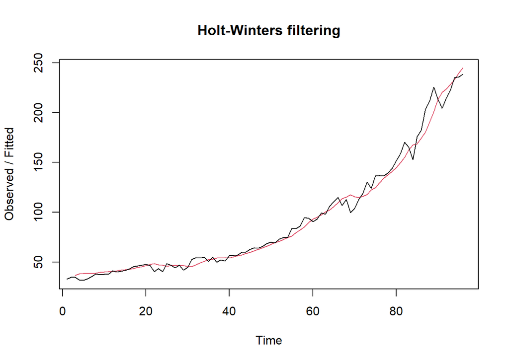

```r
plot(des.1)
```

```r
# Ramalan
ramalandes1 <- forecast(des.1, h = 24)
ramalandes1
```

```
##     Point Forecast    Lo 80    Hi 80    Lo 95    Hi 95
##  97       249.2567 240.4986 258.0149 235.8623 262.6512
##  98       254.9551 245.9482 263.9619 241.1802 268.7299
##  99       260.6534 251.3186 269.9881 246.3771 274.9296
## 100       266.3517 256.6053 276.0981 251.4459 281.2575
## 101       272.0500 261.8064 282.2937 256.3837 287.7164
## 102       277.7484 266.9222 288.5745 261.1912 294.3056
## 103       283.4467 271.9551 294.9383 265.8719 301.0215
## 104       289.1450 276.9086 301.3814 270.4311 307.8589
## 105       294.8434 281.7869 307.8998 274.8753 314.8114
## 106       300.5417 286.5945 314.4889 279.2113 321.8721
## 107       306.2400 291.3357 321.1443 283.4458 329.0342
## 108       311.9383 296.0149 327.8618 287.5855 336.2912
## 109       317.6367 300.6359 334.6374 291.6362 343.6371
## 110       323.3350 305.2024 341.4676 295.6036 351.0664
## 111       329.0333 309.7177 348.3490 299.4926 358.5741
## 112       334.7316 314.1845 355.2788 303.3075 366.1558
## 113       340.4300 318.6055 362.2545 307.0522 373.8077
## 114       346.1283 322.9829 369.2737 310.7304 381.5262
## 115       351.8266 327.3188 376.3345 314.3451 389.3081
## 116       357.5250 331.6150 383.4349 317.8991 397.1508
## 117       363.2233 335.8731 390.5734 321.3948 405.0517
## 118       368.9216 340.0946 397.7486 324.8345 413.0087
## 119       374.6199 344.2808 404.9591 328.2202 421.0197
## 120       380.3183 348.4328 412.2038 331.5536 429.0829
```

# Contoh Ramalan 2

```r
# Lambda = 0.6 dan gamma = 0.3
des.2 <- HoltWinters(train.ts, gamma = FALSE, beta = 0.3, alpha = 0.6)
des.2
```

```
## Holt-Winters exponential smoothing with trend and without seasonal component.
##
## Call:
## HoltWinters(x = train.ts, alpha = 0.6, beta = 0.3, gamma = FALSE)
##
## Smoothing parameters:
##  alpha: 0.6
##  beta : 0.3
##  gamma: FALSE
##
## Coefficients:
##         [,1]
## a 239.565068
## b   4.789104
```

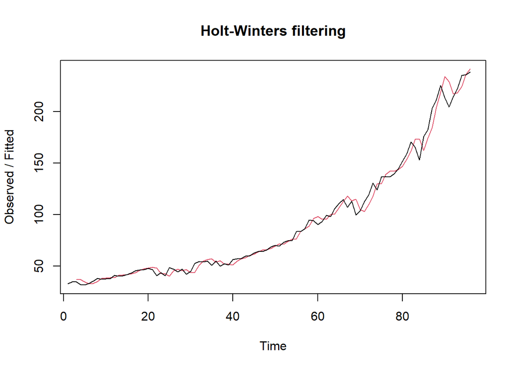

```r
plot(des.2)
```

```r
# Ramalan
ramalandes2 <- forecast(des.2, h = 24)
ramalandes2
```

```
##     Point Forecast    Lo 80    Hi 80    Lo 95    Hi 95
##  97       244.3542 235.9532 252.7551 231.5060 257.2023
##  98       249.1433 238.4889 259.7976 232.8489 265.4377
##  99       253.9324 240.5698 267.2949 233.4961 274.3687
## 100       258.7215 242.2813 275.1616 233.5784 283.8645
## 101       263.5106 243.6800 283.3412 233.1824 293.8388
## 102       268.2997 244.8040 291.7954 232.3661 304.2333
## 103       273.0888 245.6800 300.4976 231.1706 315.0069
## 104       277.8779 246.3278 309.4280 229.6262 326.1296
## 105       282.6670 246.7627 318.5713 227.7561 337.5779
## 106       287.4561 246.9969 327.9153 225.5791 349.3331
## 107       292.2452 247.0405 337.4499 223.1106 361.3799
## 108       297.0343 246.9020 347.1666 220.3635 373.7051
## 109       301.8234 246.5887 357.0581 217.3492 386.2976
## 110       306.6125 246.1071 367.1179 214.0775 399.1476
## 111       311.4016 245.4628 377.3404 210.5569 412.2463
## 112       316.1907 244.6610 387.7205 206.7955 425.5860
## 113       320.9798 243.7062 398.2534 202.8001 439.1596
## 114       325.7689 242.6027 408.9352 198.5772 452.9607
## 115       330.5580 241.3543 419.7618 194.1327 466.9834
## 116       335.3471 239.9645 430.7298 189.4719 481.2223
## 117       340.1362 238.4366 441.8359 184.6001 495.6724
## 118       344.9254 236.7737 453.0770 179.5217 510.3291
## 119       349.7145 234.9786 464.4503 174.2411 525.1878
## 120       354.5036 233.0540 475.9531 168.7625 540.2447
```

Selanjutnya jika ingin membandingkan “Plot Data Latih dan Data Uji” adalah sebagai berikut:

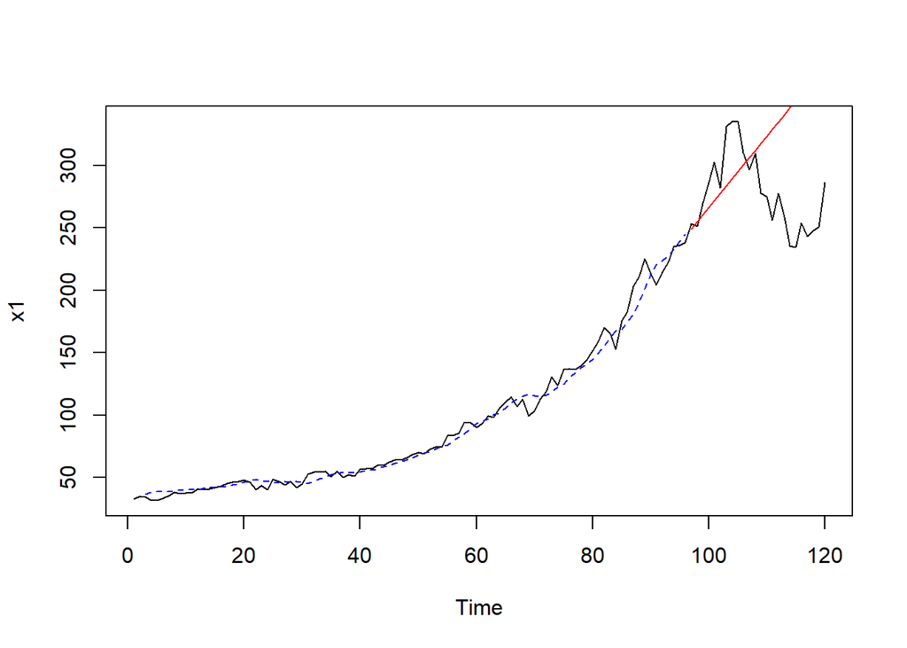

```r
# Visually Evaluate the Prediction
plot(Micros1.ts)
lines(des.1$fitted[,1], lty = 2, col = "blue")
lines(ramalandes1$mean, col = "red")
```

Untuk mendapatkan nilai parameter optimum dari DES, argumen `alpha` dan `beta` dapat dibuat `NULL` seperti berikut:

```r
# Lambda dan gamma optimum
des.opt <- HoltWinters(train.ts, gamma = FALSE)
des.opt
```

```
## Holt-Winters exponential smoothing with trend and without seasonal component.
##
## Call:
## HoltWinters(x = train.ts, gamma = FALSE)
##
## Smoothing parameters:
##  alpha: 0.9643424
##  beta : 0
##  gamma: FALSE
##
## Coefficients:
##       [,1]
## a 238.4503
## b   1.9900
```

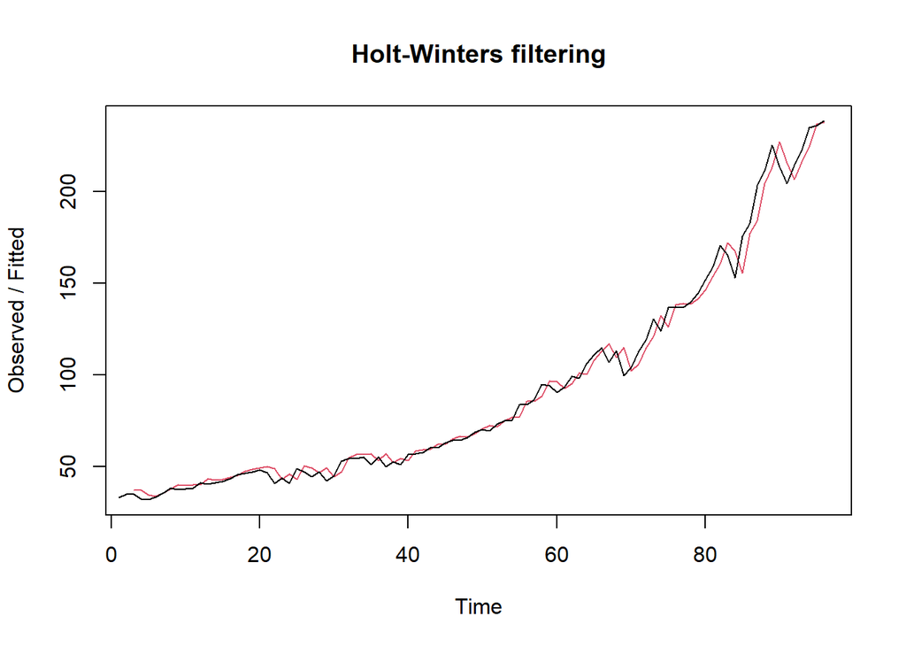

```r
plot(des.opt)
```

```r
# Ramalan
ramalandesopt <- forecast(des.opt, h = 24)
ramalandesopt
```

```
##     Point Forecast    Lo 80    Hi 80    Lo 95    Hi 95
##  97       240.4403 232.7836 248.0970 228.7303 252.1502
##  98       242.4303 231.7934 253.0672 226.1625 258.6981
##  99       244.4203 231.4718 257.3688 224.6173 264.2233
## 100       246.4103 231.5045 261.3161 223.6139 269.2067
## 101       248.4003 231.7659 265.0346 222.9602 273.8403
## 102       250.3903 232.1908 268.5898 222.5566 278.2240
## 103       252.3803 232.7400 272.0206 222.3431 282.4175
## 104       254.3703 233.3879 275.3526 222.2806 286.4600
## 105       256.3603 234.1167 278.6039 222.3416 290.3789
## 106       258.3503 234.9132 281.7874 222.5064 294.1942
## 107       260.3403 235.7676 284.9130 222.7596 297.9209
## 108       262.3303 236.6723 287.9883 223.0897 301.5709
## 109       264.3203 237.6210 291.0196 223.4872 305.1534
## 110       266.3103 238.6088 294.0118 223.9445 308.6761
## 111       268.3003 239.6316 296.9690 224.4554 312.1452
## 112       270.2903 240.6860 299.8945 225.0145 315.5661
## 113       272.2803 241.7691 302.7914 225.6175 318.9431
## 114       274.2703 242.8784 305.6622 226.2606 322.2800
## 115       276.2603 244.0117 308.5088 226.9404 325.5802
## 116       278.2503 245.1673 311.3333 227.6541 328.8464
## 117       280.2403 246.3433 314.1373 228.3993 332.0813
## 118       282.2303 247.5384 316.9222 229.1737 335.2869
## 119       284.2203 248.7514 319.6892 229.9753 338.4653
## 120       286.2103 249.9810 322.4396 230.8023 341.6183
```

Selanjutnya akan dilakukan perhitungan akurasi pada data latih maupun data uji dengan ukuran akurasi SSE, MSE dan MAPE.

# Akurasi Data Latih

```r
# Akurasi Data Training
ssedes.train1 <- des.1$SSE
ssedes.train1
```

```
## [1] 4434.903
```

```r
msedes.train1 <- ssedes.train1/length(train.ts)
msedes.train1
```

```
## [1] 46.1969
```

```r
sisaandes1 <- ramalandes1$residuals
sisaandes1
```

```
## Time Series:
## Start = 1
## End = 96
## Frequency = 1
##  [1]          NA          NA  -2.1600000  -6.3216000  -7.0180160  -5.3844282
##  [7]  -3.1421808  -1.1226956  -2.6221997  -2.5869149  -2.6652105   0.4287614
## [13]  -1.2532115  -0.9286614  -0.4318748   0.4228294   1.9596796   1.7307726
## [19]   1.2584161   1.2001943  -1.1043910  -7.7538836  -3.6133223  -6.3063403
## [25]   2.8414988   0.5461102  -2.3920451   0.4731124  -4.5836860  -1.0557774
## [31]   7.3287807   7.2032759   5.1647410   3.9773235  -1.6017035   1.9891431
## [37]  -4.3477454  -1.7533464  -3.3576933   2.2731369   1.6268756   1.0347915
## [43]   2.6797326   1.4684962   2.9807672   2.9613533   1.0273680   1.3490851
## [49]   2.7424954   2.4375238  -0.3739545   2.0718211   1.7855688  -0.1248559
## [55]   7.3217986   3.9362503   3.6803616   9.4584362   4.2425584  -2.8198461
## [61]  -2.0969759   1.8951993  -2.2368685   3.6569520   5.1157303   5.1581237
## [67]  -6.6142865  -2.1176432 -17.8356228 -12.0165816  -2.0006854   3.0420590
## [73]  12.4745722   1.2615998  11.7007579   7.1740541   2.5057289   2.1108396
## [79]   3.2604945   6.9997987   9.1312501  15.1511612   2.5910436 -14.7506921
## [85]   7.0759469   8.1942203  22.6210702  21.0377073  24.5395086   0.3493694
## [91] -16.1967168  -9.3657170  -5.7262885   1.9243058  -3.7221910  -6.3605008
```

```r
head(sisaandes1)
```

```
## Time Series:
## Start = 1
## End = 6
## Frequency = 1
## [1]        NA        NA -2.160000 -6.321600 -7.018016 -5.384428
```

```r
mapedes.train1 <- sum(abs(sisaandes1[3:length(train.ts)]/train.ts[3:length(train.ts)])
                      *100)/length(train.ts)
mapedes.train1
```

```
## [1] 5.404751
```

```r
akurasides.1 <- matrix(c(ssedes.train1, msedes.train1, mapedes.train1))
akurasides.1
```

```
##             [,1]
## [1,] 4434.902728
## [2,]   46.196903
## [3,]    5.404751
```

```r
row.names(akurasides.1) <- c("SSE", "MSE", "MAPE")
row.names(akurasides.1)
```

```
## [1] "SSE"  "MSE"  "MAPE"
```

```r
colnames(akurasides.1) <- c("Akurasi lamda = 0.2 dan gamma = 0.2")
colnames(akurasides.1)
```

```
## [1] "Akurasi lamda = 0.2 dan gamma = 0.2"
```

```r
akurasides.1
```

```
##      Akurasi lamda = 0.2 dan gamma = 0.2
## SSE                          4434.902728
## MSE                            46.196903
## MAPE                            5.404751
```

```r
ssedes.train2 <- des.2$SSE
ssedes.train2
```

```
## [1] 3998.98
```

```r
msedes.train2 <- ssedes.train2/length(train.ts)
msedes.train2
```

```
## [1] 41.65604
```

```r
sisaandes2 <- ramalandes2$residuals
sisaandes2
```

```
## Time Series:
## Start = 1
## End = 96
## Frequency = 1
##  [1]           NA           NA  -2.16000000  -5.15520000  -3.04534400
##  [6]   0.25676032   2.25138519   2.74398580  -0.71289139  -0.83732182
## [11]  -0.94637607   2.23034993  -1.04042266  -0.54145562  -0.04440679
## [16]   0.60240596   1.62269799   0.35872916  -0.43142962  -0.29983580
## [21]  -2.40322783  -7.66200363   0.76364670  -2.15354957   8.11721084
## [26]   1.26441706  -2.78429553   1.21739263  -4.73106278   1.13114636
## [31]   8.79242367   3.73429833  -0.61112550  -1.58929245  -6.16448658
## [36]   1.10504335  -5.31605248   0.56239863  -0.93745268   5.41134828
## [41]   1.91682598   0.16398838   1.59333543  -0.54172613   1.24175995
## [46]   0.62163759  -1.53830612  -0.21538850   1.54254848   0.65806454
## [51]  -2.28418065   1.63007379   0.74236228  -1.35634753   7.01831110
## [56]   0.05487855  -0.13037260   5.94899400  -2.15007828  -7.72269310
## [61]  -2.30165427   3.61105903  -1.92384627   5.31848393   4.14808891
## [66]   2.01327489 -10.80304019  -0.33501899 -15.48750709  -1.08075106
## [71]   9.75648655   9.28521401  12.94536647  -6.18073851   6.74135243
## [76]  -1.71325463  -5.54671162  -2.64168633   0.54582733   4.67258387
## [81]   4.90222139   8.79167655  -8.00504317 -20.47282328  13.33517286
## [86]   8.39804020  18.77153990   7.32206260   7.03430041 -20.35697854
## [91] -24.82923398  -2.72887404   4.40246726  10.97255968  -0.06446410
## [96]  -2.73767007
```

```r
head(sisaandes2)
```

```
## Time Series:
## Start = 1
## End = 6
## Frequency = 1
## [1]         NA         NA -2.1600000 -5.1552000 -3.0453440  0.2567603
```

```r
mapedes.train2 <- sum(abs(sisaandes2[3:length(train.ts)]/train.ts[3:length(train.ts)])
                      *100)/length(train.ts)
mapedes.train2
```

```
## [1] 4.533202
```

```r
akurasides.2 <- matrix(c(ssedes.train2, msedes.train2, mapedes.train2))
akurasides.2
```

```
##             [,1]
## [1,] 3998.980316
## [2,]   41.656045
## [3,]    4.533202
```

```r
row.names(akurasides.2) <- c("SSE", "MSE", "MAPE")
row.names(akurasides.2)
```

```
## [1] "SSE"  "MSE"  "MAPE"
```

```r
colnames(akurasides.2) <- c("Akurasi lambda = 0.6 dan gamma = 0.3")
colnames(akurasides.2)
```

```
## [1] "Akurasi lambda = 0.6 dan gamma = 0.3"
```

```r
akurasides.2
```

```
##      Akurasi lambda = 0.6 dan gamma = 0.3
## SSE                           3998.980316
## MSE                             41.656045
## MAPE                             4.533202
```

Interpretasi Hasil: = Diperoleh nilai ‘MAPE’ pada akurasi Data Latih sebesar 4,53 atau sekitar 4,5%, yang mana kurang dari 10% (Akurasi Sangat Baik).

Hasil akurasi dari data latih didapatkan skenario 2 dengan lambda=0.6 dan gamma=0.3 memiliki hasil yang lebih baik. Namun untuk kedua skenario dapat dikategorikan peramalan sangat baik berdasarkan nilai MAPE-nya.

# Akurasi Data Uji

```r
# Akurasi Data Testing
selisihdes1 <- ramalandes1$mean-testing$Price
selisihdes1
```

```
## Time Series:
## Start = 97
## End = 120
## Frequency = 1
##  [1]  -4.143271   3.725057  -8.956616 -20.008288 -30.819960  -4.371632
##  [7] -47.913304 -45.984976 -40.506648  -9.868320   9.840008   2.568336
## [13]  39.926664  48.134992  72.643320  56.911648  81.559976 110.718304
## [19] 117.226632 103.654960 120.143288 120.921616 123.859943  93.798271
```

```r
SSEtestingdes1 <- sum(selisihdes1^2)
SSEtestingdes1
```

```
## [1] 116752.4
```

```r
MSEtestingdes1 <- SSEtestingdes1/length(testing$Price)
MSEtestingdes1
```

```
## [1] 4864.685
```

```r
MAPEtestingdes1 <- sum(abs(selisihdes1/testing$Price)*100)/length(testing$Price)
MAPEtestingdes1
```

```
## [1] 20.96166
```

```r
selisihdes2 <- ramalandes2$mean-testing$Price
selisihdes2
```

```
## Time Series:
## Start = 97
## End = 120
## Frequency = 1
##  [1]  -9.045828  -2.086724 -15.677621 -27.638517 -39.359413 -13.820309
##  [7] -58.271205 -57.252101 -52.682998 -22.953894  -4.154790 -12.335686
## [13]  24.113418  31.412522  55.011625  38.370729  62.109833  90.358937
## [19]  95.958041  81.477144  97.056248  96.925352  98.954456  67.983560
```

```r
SSEtestingdes2 <- sum(selisihdes2^2)
SSEtestingdes2
```

```
## [1] 80144.99
```

```r
MSEtestingdes2 <- SSEtestingdes2/length(testing$Price)
MSEtestingdes2
```

```
## [1] 3339.375
```

```r
MAPEtestingdes2 <- sum(abs(selisihdes2/testing$Price)*100)/length(testing$Price)
MAPEtestingdes2
```

```
## [1] 18.07757
```

```r
selisihdesopt <- ramalandesopt$mean-testing$Price
selisihdesopt
```

```
## Time Series:
## Start = 97
## End = 120
## Frequency = 1
##  [1] -12.9597073  -8.7997073 -25.1897073 -39.9497073 -54.4697073 -31.7297073
##  [7] -78.9797073 -80.7597073 -78.9897073 -52.0597073 -36.0597073 -47.0397073
## [13] -13.3897073  -8.8897073  11.9102927  -7.5297073  13.4102927  38.8602927
## [19]  41.6602927  24.3802927  37.1602927  34.2302927  33.4602927  -0.3097073
```

```r
SSEtestingdesopt <- sum(selisihdesopt^2)
SSEtestingdesopt
```

```
## [1] 39821.25
```

```r
MSEtestingdesopt <- SSEtestingdesopt/length(testing$Price)
MSEtestingdesopt
```

```
## [1] 1659.219
```

```r
MAPEtestingdesopt <- sum(abs(selisihdesopt/testing$Price)*100)/length(testing$Price)
MAPEtestingdesopt
```

```
## [1] 11.82375
```

```r
akurasitestingdes <-
  matrix(c(SSEtestingdes1, MSEtestingdes1, MAPEtestingdes1, SSEtestingdes2, MSEtestingdes2,
           MAPEtestingdes2, SSEtestingdesopt, MSEtestingdesopt, MAPEtestingdesopt),
         nrow = 3, ncol = 3)
akurasitestingdes
```

```
##              [,1]        [,2]        [,3]
## [1,] 116752.43110 80144.99106 39821.24775
## [2,]   4864.68463  3339.37463  1659.21866
## [3,]     20.96166    18.07757    11.82375
```

```r
row.names(akurasitestingdes) <- c("SSE", "MSE", "MAPE")
row.names(akurasitestingdes)
```

```
## [1] "SSE"  "MSE"  "MAPE"
```

```r
colnames(akurasitestingdes) <- c("des ske1","des ske2","des opt")
colnames(akurasitestingdes)
```

```
## [1] "des ske1" "des ske2" "des opt"
```

```r
akurasitestingdes
```

```
##          des ske1    des ske2     des opt
## SSE  116752.43110 80144.99106 39821.24775
## MSE    4864.68463  3339.37463  1659.21866
## MAPE     20.96166    18.07757    11.82375
```

## Perbandingan SES dan DES

```r
MSEfull <-
  matrix(c(MSEtesting1, MSEtesting2, MSEtestingopt, MSEtestingdes1, MSEtestingdes2,
           MSEtestingdesopt), nrow = 3, ncol = 2)
MSEfull
```

```
##          [,1]     [,2]
## [1,] 34040.85 4864.685
## [2,] 20347.04 3339.375
## [3,] 19541.76 1659.219
```

```r
row.names(MSEfull) <- c("ske 1", "ske 2", "ske opt")
row.names(MSEfull)
```

```
## [1] "ske 1"   "ske 2"   "ske opt"
```

```r
colnames(MSEfull) <- c("ses", "des")
colnames(MSEfull)
```

```
## [1] "ses" "des"
```

```r
MSEfull
```

```
##              ses      des
## ske 1   34040.85 4864.685
## ske 2   20347.04 3339.375
## ske opt 19541.76 1659.219
```

Kedua metode dapat dibandingkan dengan menggunakan ukuran akurasi yang sama. Contoh di atas adalah perbandingan kedua metode dengan ukuran akurasi MSE. Hasilnya didapatkan metode DES lebih baik dibandingkan metode SES dilihat dari MSE yang lebih kecil nilainya.

# Pemulusan Data Musiman

Pertama impor kembali data baru untuk latihan data musiman.

```r
# Import data
library(rio)
Micros2 <- import("https://raw.githubusercontent.com/Mluthfialgifari/Praktikum-MPDW-Sems5/main/microsoft-stock-dataset-Monthly2.csv")
Micros2
```

```
##          Date  Price
## 1    5/1/2013  32.93
## 2    6/1/2013  34.92
## 3    7/1/2013  34.75
## 4    8/1/2013  32.06
## 5    9/1/2013  31.75
## 6   10/1/2013  33.35
## 7   11/1/2013  35.67
## 8   12/1/2013  38.09
## 9    1/1/2014  37.35
## 10   2/1/2014  37.74
## 11   3/1/2014  37.92
## 12   4/1/2014  41.15
## 13   5/1/2014  40.24
## 14   6/1/2014  40.95
```

[output cut: 106 more lines]

```r
View(Micros2)

Micros2.ts <- ts(Micros2$Price)
Micros2.ts
```

```
## Time Series:
## Start = 1
## End = 120
## Frequency = 1
##   [1]  32.93  34.92  34.75  32.06  31.75  33.35  35.67  38.09  37.35  37.74
##  [11]  37.92  41.15  40.24  40.95  41.86  43.21  45.43  46.27  46.89  47.88
##  [21]  46.66  40.59  43.67  40.60  48.58  47.06  44.46  46.98  42.17  44.75
##  [31]  52.85  54.41  54.32  54.88  50.97  55.05  50.00  52.44  51.13  56.60
##  [41]  57.01  57.41  59.97  60.11  62.79  64.36  64.13  65.81  68.68  70.24
##  [51]  69.33  73.10  74.71  74.71  83.68  83.60  86.13  94.79  93.99  90.47
##  [61]  93.21  99.28  98.10 106.03 110.85 114.75 107.05 113.00  99.55 103.78
##  [71] 112.89 118.95 130.53 123.85 136.63 137.00 136.61 139.66 144.26 151.81
##  [81] 158.78 170.43 165.31 153.00 175.80 182.54 203.14 211.52 225.51 213.49
##  [91] 204.29 214.51 222.53 235.06 235.90 238.47 253.40 251.23 269.61 286.36
## [101] 302.87 282.12 331.36 335.13 335.35 310.41 296.40 309.37 277.71 275.20
## [111] 256.39 277.82 258.87 235.41 234.60 253.87 243.08 248.00 250.76 286.52
```

Selanjutnya melakukan pembagian data dan mengubahnya menjadi data deret waktu.

```r
# Membagi data menjadi training dan testing
training <- Micros2[1:96,2]
training
```

```
##  [1]  32.93  34.92  34.75  32.06  31.75  33.35  35.67  38.09  37.35  37.74
## [11]  37.92  41.15  40.24  40.95  41.86  43.21  45.43  46.27  46.89  47.88
## [21]  46.66  40.59  43.67  40.60  48.58  47.06  44.46  46.98  42.17  44.75
## [31]  52.85  54.41  54.32  54.88  50.97  55.05  50.00  52.44  51.13  56.60
## [41]  57.01  57.41  59.97  60.11  62.79  64.36  64.13  65.81  68.68  70.24
## [51]  69.33  73.10  74.71  74.71  83.68  83.60  86.13  94.79  93.99  90.47
## [61]  93.21  99.28  98.10 106.03 110.85 114.75 107.05 113.00  99.55 103.78
## [71] 112.89 118.95 130.53 123.85 136.63 137.00 136.61 139.66 144.26 151.81
## [81] 158.78 170.43 165.31 153.00 175.80 182.54 203.14 211.52 225.51 213.49
## [91] 204.29 214.51 222.53 235.06 235.90 238.47
```

```r
testing <- Micros2[97:120,2]
testing
```

```
##  [1] 253.40 251.23 269.61 286.36 302.87 282.12 331.36 335.13 335.35 310.41
## [11] 296.40 309.37 277.71 275.20 256.39 277.82 258.87 235.41 234.60 253.87
## [21] 243.08 248.00 250.76 286.52
```

```r
training.ts <- ts(training, frequency = 12)
training.ts
```

```
##      Jan    Feb    Mar    Apr    May    Jun    Jul    Aug    Sep    Oct    Nov
## 1  32.93  34.92  34.75  32.06  31.75  33.35  35.67  38.09  37.35  37.74  37.92
## 2  40.24  40.95  41.86  43.21  45.43  46.27  46.89  47.88  46.66  40.59  43.67
## 3  48.58  47.06  44.46  46.98  42.17  44.75  52.85  54.41  54.32  54.88  50.97
## 4  50.00  52.44  51.13  56.60  57.01  57.41  59.97  60.11  62.79  64.36  64.13
## 5  68.68  70.24  69.33  73.10  74.71  74.71  83.68  83.60  86.13  94.79  93.99
## 6  93.21  99.28  98.10 106.03 110.85 114.75 107.05 113.00  99.55 103.78 112.89
## 7 130.53 123.85 136.63 137.00 136.61 139.66 144.26 151.81 158.78 170.43 165.31
## 8 175.80 182.54 203.14 211.52 225.51 213.49 204.29 214.51 222.53 235.06 235.90
##      Dec
## 1  41.15
## 2  40.60
## 3  55.05
## 4  65.81
## 5  90.47
## 6 118.95
## 7 153.00
## 8 238.47
```

```r
testing.ts <- ts(testing, frequency = 12)
testing.ts
```

```
##      Jan    Feb    Mar    Apr    May    Jun    Jul    Aug    Sep    Oct    Nov
## 1 253.40 251.23 269.61 286.36 302.87 282.12 331.36 335.13 335.35 310.41 296.40
## 2 277.71 275.20 256.39 277.82 258.87 235.41 234.60 253.87 243.08 248.00 250.76
##      Dec
## 1 309.37
## 2 286.52
```

Kemudian akan dilakukan eskplorasi dengan plot data deret waktu sebagai berikut.

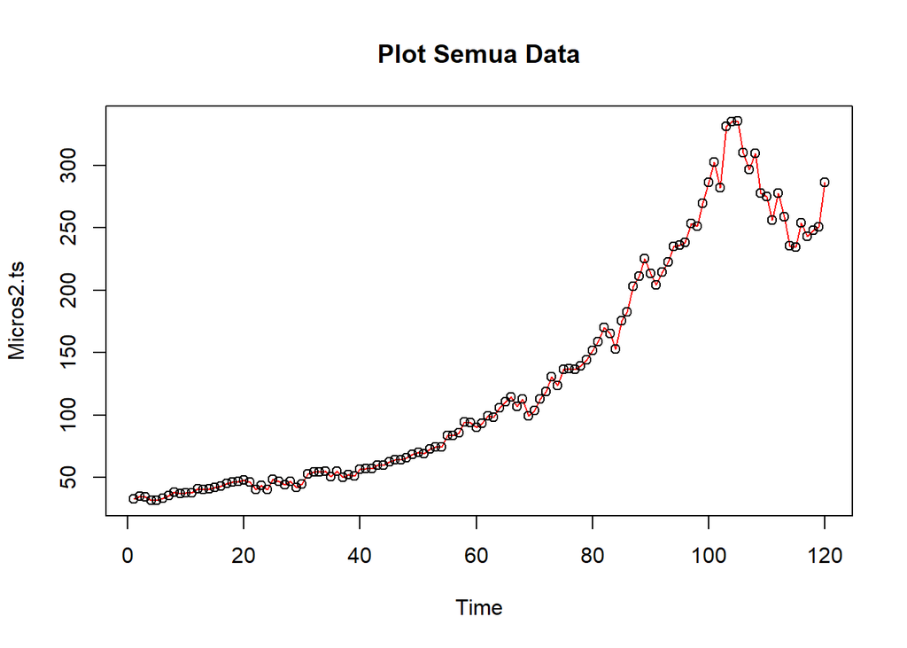

```r
# Membuat Plot Deert Waktu
plot(Micros2.ts, col = "red", main = "Plot Semua Data")
points(Micros2.ts)
```

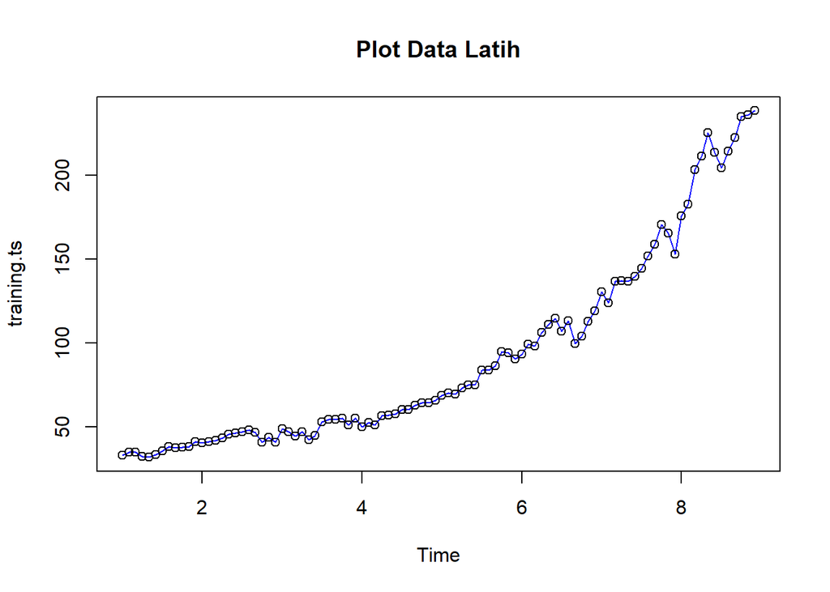

```r
plot(training.ts, col = "blue", main = "Plot Data Latih")
points(training.ts)
```

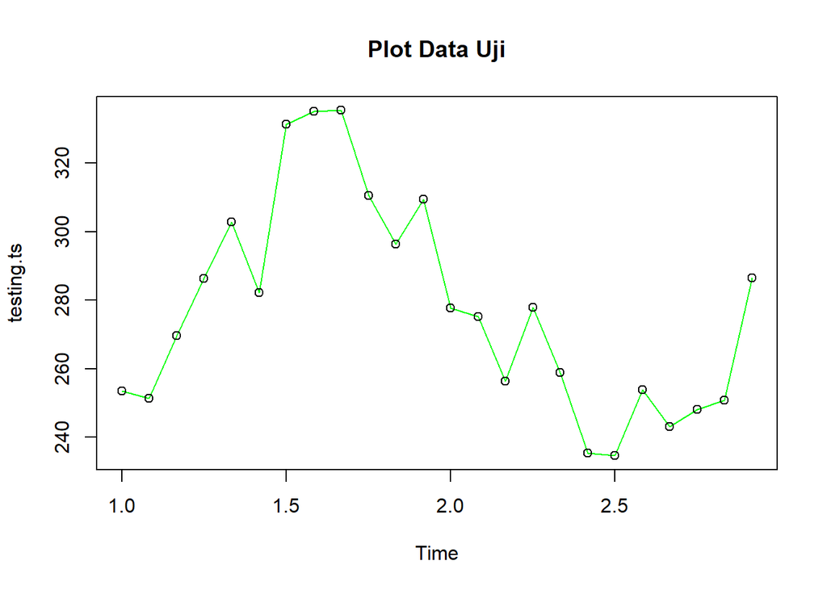

```r
plot(testing.ts, col = "green", main = "Plot Data Uji")
points(testing.ts)
```

Metode Holt-Winter untuk peramalan data musiman menggunakan tiga persamaan pemulusan yang terdiri atas persamaan untuk level $(L_t)$, trend $(B_t)$, dan komponen seasonal / musiman $(S_t)$ dengan parameter pemulusan berupa $\alpha$, $\beta$, dan $\gamma$. Metode Holt-Winter musiman terbagi menjadi dua, yaitu metode aditif dan metode multiplikatif. Perbedaan persamaan dan contoh datanya adalah sebagai berikut.

[figure not shown]

Pemulusan data musiman dengan metode Winter dilakukan menggunakan fungsi `HoltWinters()` dengan memasukkan argumen tambahan, yaitu `gamma()` dan `seasonal()` . Arguman `seasonal()` diinisialisasi menyesuaikan jenis musiman, aditif atau multiplikatif.

# Winter Aditif

Perhitungan dengan model aditif dilakukan jika plot data asli menunjukkan fluktuasi musiman yang relatif stabil (konstan).

# Pemulusan

```r
# Pemulusan dengan Winter Aditif
winter1 <- HoltWinters(training.ts, alpha = 0.2, beta = 0.1, gamma = 0.1, seasonal = "additive")
winter1
```

```
## Holt-Winters exponential smoothing with trend and additive seasonal component.
##
## Call:
## HoltWinters(x = training.ts, alpha = 0.2, beta = 0.1, gamma = 0.1,     seasonal = "additive")
##
## Smoothing parameters:
##  alpha: 0.2
##  beta : 0.1
##  gamma: 0.1
##
## Coefficients:
##            [,1]
## a   238.8754494
## b     5.3547986
## s1    1.4599804
## s2    0.8152504
## s3    2.0093695
## s4    2.9956786
## s5    3.9031413
## s6    2.5321225
## s7    0.1379385
## s8    2.0421118
## s9    0.7096535
## s10   1.8883560
## s11   0.1304933
## s12  -0.3524714
```

```r
winter1$fitted
```

```
##            xhat     level     trend      season
## Jan 2  34.77383  35.03982 0.7868925 -1.05288194
## Feb 2  36.59786  36.91994 0.8962159 -1.21829861
## Mar 2  38.56571  38.68659 0.9832587 -1.10413194
## Apr 2  41.11705  40.32870 1.0491444 -0.26079861
## May 2  44.48831  41.79644 1.0910034  1.60086806
## Jun 2  46.40982  43.07578 1.1098372  2.22420139
## Jul 2  44.65473  44.15765 1.1070409 -0.60996528
## Aug 2  48.11770  45.71175 1.1517463  1.25420139
## Sep 2  47.92965  46.81596 1.1469924 -0.03329861
## Oct 2  48.42649  47.70902 1.1215994 -0.40413194
## Nov 2  46.96947  47.26332 0.9648697 -1.25871528
## Dec 2  49.33013  47.56830 0.8988802  0.86295139
## Jan 3  46.82984  46.72115 0.7242777 -0.61558814
## Feb 3  47.68461  47.79546 0.7592809 -0.87012751
## Mar 3  48.33602  48.42982 0.7467886 -0.84058909
## Apr 3  48.97731  48.40140 0.6692683 -0.09336255
## May 3  50.97673  48.67121 0.6293221  1.67620330
## Jun 3  50.20539  47.53918 0.4531874  2.21301593
## Jul 3  46.81423  46.90129 0.3440796 -0.43114358
## Aug 3  50.15251  48.45253 0.4647950  1.23518571
## Sep 3  50.18390  49.76882 0.5499448 -0.13487055
## Oct 3  50.74760  51.14599 0.6326669 -1.03105078
## Nov 3  51.79777  52.60513 0.7153149 -1.52267325
## Dec 3  54.01819  53.15489 0.6987594  0.16454126
## Jan 4  54.30383  54.06001 0.7193955 -0.47557530
## Feb 4  53.63186  53.91864 0.6333188 -0.92009655
## Mar 4  53.77240  54.31359 0.6094815 -1.15067049
## Apr 4  54.69808  54.39459 0.5566335 -0.25314725
## May 4  56.89794  55.33161 0.5946720  0.97166450
## Jun 4  58.32219  55.94869 0.5969131  1.77658489
## Jul 4  56.99355  56.36317 0.5786693  0.05171798
## Aug 4  59.75111  57.53713 0.6381982  1.57578501
## Sep 4  59.08850  58.24710 0.6453761  0.19601781
## Oct 4  59.65173  59.63278 0.7194062 -0.70045903
## Nov 4  60.51852  61.29384 0.8135717 -1.58889525
## Dec 4  63.96260  62.82971 0.8858013  0.24708575
## Jan 5  64.18786  64.08499 0.9227494 -0.81988202
## Feb 5  65.90331  65.90617 1.0125923 -1.01544574
## Mar 5  67.52336  67.78610 1.0993260 -1.36206244
```

[output cut: 30 more lines]

```
## Oct 7 152.60617 149.67125 3.0894633 -0.15454173
## Nov 7 159.16164 156.32548 3.4459399 -0.60977673
## Dec 7 165.19936 161.00109 3.5689070  0.62936389
## Jan 8 166.14242 162.13012 3.3249198  0.68737379
## Feb 8 170.77900 167.38656 3.5180715 -0.12562945
## Mar 8 176.92206 173.25683 3.7532914 -0.08806590
## Apr 8 187.61461 182.25371 4.2776503  1.08324733
## May 8 197.75059 191.31244 4.7557581  1.68238821
## Jun 8 209.11299 201.62008 5.3109464  2.18196166
## Jul 8 214.13006 207.80643 5.3984866  0.92514328
## Aug 8 218.82598 211.23690 5.2016854  2.38739014
## Sep 8 221.30219 215.57539 5.1153658  0.61142856
## Oct 8 227.34761 220.93632 5.1399221  1.27136470
## Nov 8 232.79498 227.61872 5.2941699 -0.11790797
## Dec 8 238.54358 233.53390 5.3562702 -0.34658492
```

```r
xhat1 <- winter1$fitted[,2]
xhat1
```

```
##         Jan       Feb       Mar       Apr       May       Jun       Jul
## 2  35.03982  36.91994  38.68659  40.32870  41.79644  43.07578  44.15765
## 3  46.72115  47.79546  48.42982  48.40140  48.67121  47.53918  46.90129
## 4  54.06001  53.91864  54.31359  54.39459  55.33161  55.94869  56.36317
## 5  64.08499  65.90617  67.78610  69.24675  70.94597  72.45612  73.54510
## 6  90.59692  92.78881  95.81556  98.19343 101.43579 104.88639 108.41562
## 7 115.74065 120.30519 122.80935 127.56457 131.31084 134.12780 136.90420
## 8 162.13012 167.38656 173.25683 182.25371 191.31244 201.62008 207.80643
##         Aug       Sep       Oct       Nov       Dec
## 2  45.71175  46.81596  47.70902  47.26332  47.56830
## 3  48.45253  49.76882  51.14599  52.60513  53.15489
## 4  57.53713  58.24710  59.63278  61.29384  62.82971
## 5  76.48227  78.69124  81.25296  85.28523  88.74285
## 6 109.92653 112.05725 111.25284 111.25695 113.18039
## 7 140.36274 144.45745 149.67125 156.32548 161.00109
## 8 211.23690 215.57539 220.93632 227.61872 233.53390
```

```r
winter1.opt <- HoltWinters(training.ts, alpha= NULL,  beta = NULL, gamma = NULL, seasonal = "additive")
winter1.opt
```

```
## Holt-Winters exponential smoothing with trend and additive seasonal component.
##
## Call:
## HoltWinters(x = training.ts, alpha = NULL, beta = NULL, gamma = NULL,     seasonal = "additive")
##
## Smoothing parameters:
##  alpha: 0.884612
##  beta : 0.05069112
##  gamma: 0.6338297
##
## Coefficients:
##            [,1]
## a   239.7326855
## b     4.1939350
## s1    1.9539073
## s2   -0.5407314
## s3    0.4109345
## s4    0.5751105
## s5    1.5300217
## s6    0.7537690
## s7   -0.1355723
## s8    1.9673309
## s9    0.2641821
## s10   1.2846438
## s11  -1.3303394
## s12  -1.1764388
```

```r
winter1.opt$fitted
```

```
##            xhat     level     trend       season
## Jan 2  34.77383  35.03982 0.7868925 -1.052881944
## Feb 2  40.47586  40.66215 1.0320064 -1.218298611
## Mar 2  42.06272  42.11359 1.0532678 -1.104131944
## Apr 2  43.77090  42.98752 1.0441773 -0.260798611
## May 2  46.15541  43.53552 1.0190253  1.600868056
## Jun 2  47.12353  43.91284 0.9864963  2.224201389
## Jul 2  44.48254  44.14429 0.9482222 -0.609965278
## Aug 2  49.53255  47.22217 1.0561773  1.254201389
## Sep 2  47.76526  46.81648 0.9820736 -0.033298611
## Oct 2  47.34921  46.82083 0.9325117 -0.404131944
## Nov 2  41.14476  41.77406 0.6294153 -1.258715278
## Dec 2  46.24294  44.63733 0.7426518  0.862951389
## Jan 3  40.22468  40.38818 0.4896114 -0.653106019
## Feb 3  47.94966  48.26900 0.8642804 -1.183621667
## Mar 3  48.05171  48.34628 0.8243862 -1.118958462
## Apr 3  46.35490  45.99340 0.6633271 -0.301820980
## May 3  49.44886  47.20969 0.6913576  1.547813964
## Jun 3  43.98882  41.46208 0.3649590  2.161777048
## Jul 3  42.46559  42.50039 0.3990920 -0.433892660
## Aug 3  54.08375  52.08566 0.8647494  1.133339738
## Sep 3  54.00426  53.23901 0.8793793 -0.114133176
## Oct 3  54.39276  54.39770 0.8935377 -0.898476053
## Nov 3  55.56361  55.72225 0.9153864 -1.074028722
## Dec 3  53.73372  52.57408 0.7093997  0.450247588
## Jan 4  55.17427  54.44787 0.7684241 -0.042028476
## Feb 4  49.92679  50.63908 0.5363999 -1.248688239
## Mar 4  52.66615  53.39869 0.6490972 -1.381642717
## Apr 4  53.01301  52.68890 0.5802133 -0.256103763
## May 4  58.19873  56.44221 0.7410612  1.015464395
## Jun 4  59.03690  56.13170 0.6877561  2.217447290
## Jul 4  56.32067  55.38028 0.6148025  0.325585163
## Aug 4  61.15897  59.22333 0.7784458  1.157200806
## Sep 4  59.71420  59.07384 0.7314079 -0.091041140
## Oct 4  62.53262  62.52613 0.8693326 -0.862841258
## Nov 4  64.55327  65.01198 0.9512758 -1.409988773
## Dec 4  67.06764  65.58883 0.9322955  0.546515228
## Jan 5  65.86405  65.40860 0.8759004 -0.420455392
## Feb 5  68.71282  68.77553 1.0021733 -1.064881103
## Mar 5  70.70533  71.12866 1.0706551 -1.493991000
```

[output cut: 30 more lines]

```
## Oct 7 161.58780 158.71466 2.8559619  0.017177132
## Nov 7 171.83069 169.39254 3.2524637 -0.814314372
## Dec 7 170.05714 166.87672 2.9600632  0.220348522
## Jan 8 157.56316 154.74784 2.1951877  0.620131226
## Feb 8 174.99605 173.07556 3.0129636 -1.092468335
## Mar 8 185.21306 182.76199 3.3512491 -0.900176522
## Apr 8 206.32167 201.97162 4.1551284  0.194923966
## May 8 215.94387 210.72525 4.3882315  0.830390102
## Jun 8 230.38219 223.57579 4.8171955  1.989202277
## Jul 8 218.40653 213.44995 4.0597164  0.896859246
## Aug 8 210.09301 205.02202 3.4267034  1.644288368
## Sep 8 215.74906 212.35604 3.6247699 -0.231750857
## Oct 8 226.57202 221.97931 3.9288404  0.663863598
## Nov 8 236.43497 233.41672 4.3094584 -1.291213716
## Dec 8 240.51126 237.25294 4.2854693 -1.027148154
```

```r
xhat1.opt <- winter1.opt$fitted[,2]
xhat1.opt
```

```
##         Jan       Feb       Mar       Apr       May       Jun       Jul
## 2  35.03982  40.66215  42.11359  42.98752  43.53552  43.91284  44.14429
## 3  40.38818  48.26900  48.34628  45.99340  47.20969  41.46208  42.50039
## 4  54.44787  50.63908  53.39869  52.68890  56.44221  56.13170  55.38028
## 5  65.40860  68.77553  71.12866  70.98269  72.96660  73.80957  72.87064
## 6  90.85436  93.29215  99.60241  99.88237 105.43382 109.63225 112.67504
## 7 118.55777 129.47616 125.25390 137.06025 136.92914 135.93844 137.69057
## 8 154.74784 173.07556 182.76199 201.97162 210.72525 223.57579 213.44995
##         Aug       Sep       Oct       Nov       Dec
## 2  47.22217  46.81648  46.82083  41.77406  44.63733
## 3  52.08566  53.23901  54.39770  55.72225  52.57408
## 4  59.22333  59.07384  62.52613  65.01198  65.58883
## 5  82.01786  82.61885  85.75915  94.55639  95.53659
## 6 106.80812 111.57221 100.89111 103.68419 113.30362
## 7 143.20234 149.95385 158.71466 169.39254 166.87672
## 8 205.02202 212.35604 221.97931 233.41672 237.25294
```

# Peramalan

```r
# Forecasting
forecast1 <- predict(winter1, n.ahead = 24)
forecast1
```

```
##         Jan      Feb      Mar      Apr      May      Jun      Jul      Aug
## 9  245.6902 250.4003 256.9492 263.2903 269.5526 273.5364 276.4970 283.7559
## 10 309.9478 314.6579 321.2068 327.5479 333.8102 337.7939 340.7546 348.0135
##         Sep      Oct      Nov      Dec
## 9  287.7783 294.3118 297.9087 302.7806
## 10 352.0359 358.5694 362.1663 367.0381
```

```r
forecast1.opt <- predict(winter1.opt, n.ahead = 24)
forecast1.opt
```

```
##         Jan      Feb      Mar      Apr      May      Jun      Jul      Aug
## 9  245.8805 247.5798 252.7254 257.0835 262.2324 265.6501 268.9547 275.2515
## 10 296.2077 297.9070 303.0526 307.4108 312.5596 315.9773 319.2819 325.5787
##         Sep      Oct      Nov      Dec
## 9  277.7423 282.9567 284.5356 288.8835
## 10 328.0695 333.2839 334.8629 339.2107
```

# Plot Deret Waktu

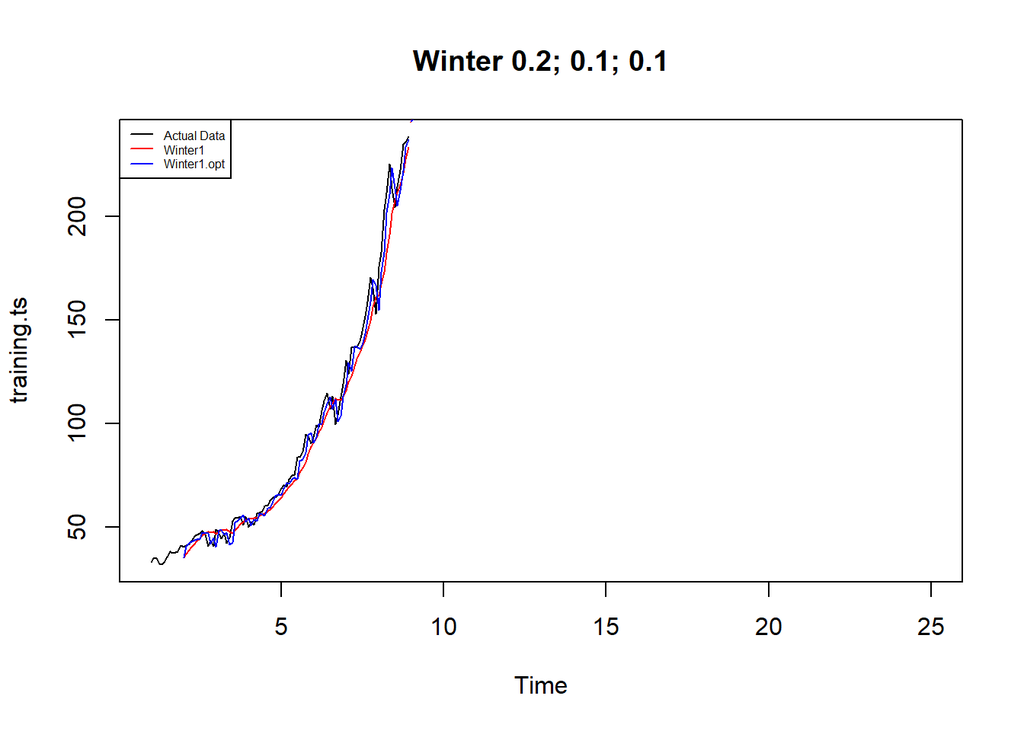

```r
plot(training.ts, main = "Winter 0.2; 0.1; 0.1", type = "l", col = "black",
     xlim = c(1, 25), pch = 12)
lines(xhat1, type = "l", col = "red")
lines(xhat1.opt, type = "l", col = "blue")
lines(forecast1, type = "l", col = "red")
lines(forecast1.opt, type = "l", col = "blue")
legend("topleft", c("Actual Data", expression(paste(Winter1)),
                   expression(paste(Winter1.opt))), cex = 0.5,
       col = c("black","red","blue"), lty = 1)
```

# Akurasi Data Latih

```r
# Akurasi Data Training
SSE1 <- winter1$SSE
SSE1
```

```
## [1] 5006.131
```

```r
MSE1 <- winter1$SSE/length(training.ts)
MSE1
```

```
## [1] 52.1472
```

```r
RMSE1 <- sqrt(MSE1)
RMSE1
```

```
## [1] 7.221302
```

```r
akurasi1 <- matrix(c(SSE1, MSE1, RMSE1))
akurasi1
```

```
##             [,1]
## [1,] 5006.130784
## [2,]   52.147196
## [3,]    7.221302
```

```r
row.names(akurasi1) <- c("SSE", "MSE", "RMSE")
row.names(akurasi1)
```

```
## [1] "SSE"  "MSE"  "RMSE"
```

```r
colnames(akurasi1) <- c("Akurasi")
colnames(akurasi1)
```

```
## [1] "Akurasi"
```

```r
akurasi1
```

```
##          Akurasi
## SSE  5006.130784
## MSE    52.147196
## RMSE    7.221302
```

```r
SSE1.opt <- winter1.opt$SSE
SSE1.opt
```

```
## [1] 3433.407
```

```r
MSE1.opt <- winter1.opt$SSE/length(training.ts)
MSE1.opt
```

```
## [1] 35.76465
```

```r
RMSE1.opt <- sqrt(MSE1.opt)
RMSE1.opt
```

```
## [1] 5.980356
```

```r
akurasi1.opt <- matrix(c(SSE1.opt, MSE1.opt, RMSE1.opt))
akurasi1.opt
```

```
##             [,1]
## [1,] 3433.406766
## [2,]   35.764654
## [3,]    5.980356
```

```r
row.names(akurasi1.opt) <- c("SSE1.opt", "MSE1.opt", "RMSE1.opt")
row.names(akurasi1.opt)
```

```
## [1] "SSE1.opt"  "MSE1.opt"  "RMSE1.opt"
```

```r
colnames(akurasi1.opt) <- c("Akurasi")
colnames(akurasi1.opt)
```

```
## [1] "Akurasi"
```

```r
akurasi1.opt
```

```
##               Akurasi
## SSE1.opt  3433.406766
## MSE1.opt    35.764654
## RMSE1.opt    5.980356
```

```r
akurasi1.train = data.frame(Model_Winter = c("Winter 1", "Winter1 optimal"),
                            Nilai_SSE = c(SSE1, SSE1.opt),
                            Nilai_MSE = c(MSE1, MSE1.opt), Nilai_RMSE = c(RMSE1, RMSE1.opt))
akurasi1.train
```

```
##      Model_Winter Nilai_SSE Nilai_MSE Nilai_RMSE
## 1        Winter 1  5006.131  52.14720   7.221302
## 2 Winter1 optimal  3433.407  35.76465   5.980356
```

# Akurasi Data Uji

```r
# Akurasi Data Testing
forecast1 <- data.frame(forecast1)
forecast1
```

```
##         fit
## 1  245.6902
## 2  250.4003
## 3  256.9492
## 4  263.2903
## 5  269.5526
## 6  273.5364
## 7  276.4970
## 8  283.7559
## 9  287.7783
## 10 294.3118
## 11 297.9087
## 12 302.7806
## 13 309.9478
## 14 314.6579
## 15 321.2068
## 16 327.5479
## 17 333.8102
## 18 337.7939
## 19 340.7546
## 20 348.0135
## 21 352.0359
## 22 358.5694
## 23 362.1663
## 24 367.0381
```

```r
testing.ts <- data.frame(testing.ts)
testing.ts
```

```
##    testing.ts
## 1      253.40
## 2      251.23
## 3      269.61
## 4      286.36
## 5      302.87
## 6      282.12
## 7      331.36
## 8      335.13
## 9      335.35
## 10     310.41
## 11     296.40
## 12     309.37
## 13     277.71
## 14     275.20
## 15     256.39
## 16     277.82
## 17     258.87
## 18     235.41
## 19     234.60
## 20     253.87
## 21     243.08
## 22     248.00
## 23     250.76
## 24     286.52
```

```r
selisih1 <- forecast1-testing.ts
selisih1
```

```
##            fit
## 1   -7.7097717
## 2   -0.8297031
## 3  -12.6607853
## 4  -23.0696776
## 5  -33.3174163
## 6   -8.5836365
## 7  -54.8630219
## 8  -51.3740500
## 9  -47.5717097
## 10 -16.0982086
## 11   1.5087273
## 12  -6.5894388
## 13  32.2378116
## 14  39.4578801
## 15  64.8167979
## 16  49.7279056
## 17  74.9401669
## 18 102.3839467
## 19 106.1545613
## 20  94.1435332
## 21 108.9558735
## 22 110.5693746
## 23 111.4063105
## 24  80.5181444
```

```r
SSEtesting1 <- sum(selisih1^2)
SSEtesting1
```

```
## [1] 98645.61
```

```r
MSEtesting1 <- SSEtesting1/length(testing.ts)
MSEtesting1
```

```
## [1] 98645.61
```

```r
forecast1.opt <- data.frame(forecast1.opt)
forecast1.opt
```

```
##         fit
## 1  245.8805
## 2  247.5798
## 3  252.7254
## 4  257.0835
## 5  262.2324
## 6  265.6501
## 7  268.9547
## 8  275.2515
## 9  277.7423
## 10 282.9567
## 11 284.5356
## 12 288.8835
## 13 296.2077
## 14 297.9070
## 15 303.0526
## 16 307.4108
## 17 312.5596
## 18 315.9773
## 19 319.2819
## 20 325.5787
## 21 328.0695
## 22 333.2839
## 23 334.8629
## 24 339.2107
```

```r
selisih1.opt <- forecast1.opt-testing.ts
selisih1.opt
```

```
##           fit
## 1   -7.519472
## 2   -3.650176
## 3  -16.884575
## 4  -29.276464
## 5  -40.637618
## 6  -16.469936
## 7  -62.405342
## 8  -59.878504
## 9  -57.607718
## 10 -27.453321
## 11 -11.864369
## 12 -20.486533
## 13  18.497748
## 14  22.707044
## 15  46.662645
## 16  29.590756
## 17  53.689602
## 18  80.567284
## 19  84.681878
## 20  71.708716
## 21  84.989502
## 22  85.283899
## 23  84.102851
## 24  52.690686
```

```r
SSEtesting1.opt <- sum(selisih1.opt^2)
SSEtesting1.opt
```

```
## [1] 65191.17
```

```r
MSEtesting1.opt <- SSEtesting1.opt/length(testing.ts)
MSEtesting1.opt
```

```
## [1] 65191.17
```

# Winter Multiplikatif

Model multiplikatif digunakan cocok digunakan jika plot data asli menunjukkan fluktuasi musiman yang bervariasi.

# Pemulusan

```r
# Pemulusan dengan Winter Multiplikatif
winter2 <- HoltWinters(training.ts, alpha = 0.2, beta = 0.1, gamma = 0.3, seasonal = "multiplicative")
winter2
```

```
## Holt-Winters exponential smoothing with trend and multiplicative seasonal component.
##
## Call:
## HoltWinters(x = training.ts, alpha = 0.2, beta = 0.1, gamma = 0.3,     seasonal = "multiplicative")
##
## Smoothing parameters:
##  alpha: 0.2
##  beta : 0.1
##  gamma: 0.3
##
## Coefficients:
##           [,1]
## a   234.304038
## b     5.248682
## s1    1.042171
## s2    1.030367
## s3    1.045741
## s4    1.058410
## s5    1.058435
## s6    1.034182
## s7    1.019043
## s8    1.041972
## s9    1.026638
## s10   1.045979
## s11   1.021645
## s12   1.001370
```

```r
winter2$fitted
```

```
##            xhat     level     trend    season
## Jan 2  34.91795  35.03982 0.7868925 0.9746346
## Feb 2  36.72115  36.91882 0.8961036 0.9710757
## Mar 2  38.64258  38.68589 0.9831998 0.9741233
## Apr 2  41.11940  40.32966 1.0492575 0.9937281
## May 2  44.44260  41.79968 1.0913335 1.0361752
## Jun 2  46.40614  43.08160 1.1103919 1.0501029
## Jul 2  44.56916  44.16606 1.1077991 0.9844348
## Aug 2  48.55190  45.74537 1.1549497 1.0352148
## Sep 2  47.91734  46.77051 1.1419688 1.0001016
## Oct 2  48.30028  47.66103 1.1168245 0.9902090
## Nov 2  46.66065  47.22055 0.9610942 0.9684320
## Dec 2  49.51830  47.56402 0.8993314 1.0217679
## Jan 3  47.88044  46.71769 0.7247654 1.0092319
## Feb 3  48.18977  47.58109 0.7386286 0.9973106
## Mar 3  48.48064  48.09315 0.7159722 0.9932700
## Apr 3  48.91332  47.99955 0.6350145 1.0057317
## May 3  50.88240  48.25010 0.5965685 1.0416758
## Jun 3  49.95304  47.17391 0.4292919 1.0493631
## Jul 3  46.78258  46.61154 0.3301262 0.9966109
## Aug 3  50.15539  48.15928 0.4518873 1.0317670
## Sep 3  49.65894  49.43589 0.5343595 0.9937702
## Oct 3  49.01228  50.90830 0.6281651 0.9510213
## Nov 3  51.02477  52.77045 0.7515633 0.9533417
## Dec 3  52.95610  53.51052 0.7504144 0.9759524
## Jan 4  56.19136  54.69004 0.7933243 1.0127605
## Feb 4  54.47432  54.26069 0.6710573 0.9916727
## Mar 4  53.67160  54.52147 0.6300293 0.9731666
## Apr 4  54.99249  54.62916 0.5777957 0.9961152
## May 4  55.99107  55.52972 0.6100713 0.9973510
## Jun 4  58.26071  56.34411 0.6305040 1.0225730
## Jul 4  58.96375  56.80823 0.6138655 1.0268477
## Aug 4  61.30522  57.61809 0.6334643 1.0524221
## Sep 4  59.55832  58.02441 0.6107507 1.0157441
## Oct 4  58.60953  59.27148 0.6743824 0.9777077
## Nov 4  59.01018  61.12218 0.7920140 0.9530961
## Dec 4  62.93871  62.98855 0.8994497 0.9851413
## Jan 5  64.47181  64.47092 0.9577417 0.9853756
## Feb 5  66.16241  66.28279 1.0431547 0.9827178
## Mar 5  66.64928  68.15581 1.1261408 0.9620007
```

[output cut: 30 more lines]

```
## Oct 7 152.17815 147.46030 2.9977748 1.0114323
## Nov 7 158.20959 154.06718 3.3586858 1.0049783
## Dec 7 164.12659 158.83891 3.4999906 1.0110121
## Jan 8 168.59449 160.13783 3.2798827 1.0316782
## Feb 8 170.49157 164.81456 3.4195678 1.0134184
## Mar 8 175.89909 170.61191 3.6573458 1.0093524
## Apr 8 189.42061 179.66695 4.1971159 1.0302209
## May 8 197.51116 188.15429 4.6261382 1.0245395
## Jun 8 209.39235 198.24608 5.1727026 1.0293659
## Jul 8 216.39384 204.21493 5.2523177 1.0330677
## Aug 8 223.13109 207.12397 5.0179896 1.0518009
## Sep 8 220.64075 210.50265 4.8540595 1.0245362
## Oct 8 229.41118 215.72551 4.8909395 1.0398643
## Nov 8 230.26327 221.70291 4.9995849 1.0157068
## Dec 8 231.60383 227.81241 5.1105763 0.9943365
```

```r
xhat2 <- winter2$fitted[,2]
xhat2
```

```
##         Jan       Feb       Mar       Apr       May       Jun       Jul
## 2  35.03982  36.91882  38.68589  40.32966  41.79968  43.08160  44.16606
## 3  46.71769  47.58109  48.09315  47.99955  48.25010  47.17391  46.61154
## 4  54.69004  54.26069  54.52147  54.62916  55.52972  56.34411  56.80823
## 5  64.47092  66.28279  68.15581  69.83927  71.39227  73.00578  74.07507
## 6  90.37105  92.49102  95.48387  98.24721 101.32174 104.83573 108.35101
## 7 114.07320 118.75522 121.22267 126.59806 130.10623 132.85443 135.50720
## 8 160.13783 164.81456 170.61191 179.66695 188.15429 198.24608 204.21493
##         Aug       Sep       Oct       Nov       Dec
## 2  45.74537  46.77051  47.66103  47.22055  47.56402
## 3  48.15928  49.43589  50.90830  52.77045  53.51052
## 4  57.61809  58.02441  59.27148  61.12218  62.98855
## 5  76.48384  78.23438  80.44748  84.49261  88.30906
## 6 109.05499 110.53083 109.31851 108.97517 111.07825
## 7 138.51118 141.99233 147.46030 154.06718 158.83891
## 8 207.12397 210.50265 215.72551 221.70291 227.81241
```

```r
winter2.opt <- HoltWinters(training.ts, alpha= NULL,  beta = NULL, gamma = NULL, seasonal = "multiplicative")
winter2.opt
```

```
## Holt-Winters exponential smoothing with trend and multiplicative seasonal component.
##
## Call:
## HoltWinters(x = training.ts, alpha = NULL, beta = NULL, gamma = NULL,     seasonal = "multiplicative")
##
## Smoothing parameters:
##  alpha: 0.8838079
##  beta : 0.04147053
##  gamma: 0.8044744
##
## Coefficients:
##            [,1]
## a   242.1635196
## b     4.0052683
## s1    1.0143999
## s2    0.9855139
## s3    0.9805533
## s4    0.9981085
## s5    1.0155668
## s6    1.0292797
## s7    1.0166209
## s8    1.0338171
## s9    1.0074109
## s10   1.0037962
## s11   0.9743290
## s12   0.9851688
```

```r
winter2.opt$fitted
```

```
##            xhat     level     trend    season
## Jan 2  34.91795  35.03982 0.7868925 0.9746346
## Feb 2  40.43542  40.65279 0.9870327 0.9710757
## Mar 2  41.99895  42.10816 1.0064548 0.9741233
## Apr 2  43.71387  42.98855 1.0012267 0.9937281
## May 2  46.13495  43.54163 0.9826421 1.0361752
## Jun 2  47.12935  43.92299 0.9577063 1.0501029
## Jul 2  44.38339  44.15743 0.9277124 0.9844348
## Aug 2  50.05944  47.33554 1.0210373 1.0352148
## Sep 2  47.44459  46.49589 0.9438738 1.0001016
## Oct 2  47.19488  46.74641 0.9151201 0.9902090
## Nov 2  41.09736  41.76637 0.6706445 0.9684320
## Dec 2  46.54445  44.78485 0.7680104 1.0217679
## Jan 3  40.42800  40.41104 0.5547763 0.9868717
## Feb 3  47.75923  48.26646 0.8575380 0.9722180
## Mar 3  48.02840  48.48835 0.8311775 0.9738212
## Apr 3  46.43385  46.08097 0.6968725 0.9926464
## May 3  49.64489  47.26410 0.7170382 1.0346750
## Jun 3  44.07869  41.59618 0.4522503 1.0482838
## Jul 3  42.63272  42.61441 0.4757220 0.9893846
## Aug 3  54.70773  52.21714 0.8542237 1.0308333
## Sep 3  53.58100  52.81610 0.8436378 0.9985328
## Oct 3  53.82855  54.31383 0.8707633 0.9754272
## Nov 3  55.55299  56.13728 0.9102718 0.9738016
## Dec 3  54.05584  52.88809 0.7377769 1.0080180
## Jan 4  55.41842  54.49753 0.7739250 1.0026590
## Feb 4  49.58346  50.49531 0.5758559 0.9708700
## Mar 4  52.53884  53.67154 0.6836949 0.9665828
## Apr 4  53.36045  53.06705 0.6302729 0.9937265
## May 4  58.35319  56.57853 0.7497584 1.0178776
## Jun 4  59.69273  56.16202 0.7013926 1.0497563
## Jul 4  55.98966  54.94155 0.6216916 1.0076745
## Aug 4  61.63372  59.05430 0.7664679 1.0303064
## Sep 4  59.21439  58.51371 0.7122632 0.9998046
## Oct 4  61.78704  62.38674 0.8433419 0.9771780
## Nov 4  64.21630  65.55719 0.9398485 0.9657017
## Dec 4  68.00953  66.41806 0.9365731 1.0097231
## Jan 5  65.79751  65.42939 0.8567324 0.9926288
## Feb 5  68.12936  68.85261 0.9631658 0.9758449
## Mar 5  70.15744  71.72734 1.0424396 0.9641012
```

[output cut: 30 more lines]

```
## Oct 7 159.70374 158.14221 2.6013003 0.9935315
## Nov 7 168.87232 170.28519 2.9969985 0.9745510
## Dec 7 172.69716 170.05156 2.8630229 0.9987426
## Jan 8 158.41256 155.48417 2.1401741 1.0050006
## Feb 8 172.22888 172.91503 2.7742872 0.9803037
## Mar 8 182.75174 184.98546 3.1598033 0.9713332
## Apr 8 210.09467 206.69638 3.9291277 0.9974797
## May 8 218.60215 211.88840 3.9815008 1.0126569
## Jun 8 234.93141 221.89881 4.2315228 1.0389204
## Jul 8 216.03121 207.89016 3.4750933 1.0220753
## Aug 8 210.83594 201.21242 3.0540495 1.0321613
## Sep 8 211.14160 207.41244 3.1845149 1.0025862
## Oct 8 224.10680 220.63616 3.6008457 0.9994194
## Nov 8 231.40481 233.92315 4.0025353 0.9725928
## Dec 8 242.95773 242.01052 4.1719357 0.9869011
```

```r
xhat2.opt <- winter2.opt$fitted[,2]
xhat2.opt
```

```
##         Jan       Feb       Mar       Apr       May       Jun       Jul
## 2  35.03982  40.65279  42.10816  42.98855  43.54163  43.92299  44.15743
## 3  40.41104  48.26646  48.48835  46.08097  47.26410  41.59618  42.61441
## 4  54.49753  50.49531  53.67154  53.06705  56.57853  56.16202  54.94155
## 5  65.42939  68.85261  71.72734  72.01126  73.15055  73.62996  71.80392
## 6  90.93754  93.38761 100.67571 101.91753 105.80889 109.02852 110.24741
## 7 119.05364 129.65454 126.47507 140.35696 137.48207 135.02208 134.49267
## 8 155.48417 172.91503 184.98546 206.69638 211.88840 221.89881 207.89016
##         Aug       Sep       Oct       Nov       Dec
## 2  47.33554  46.49589  46.74641  41.76637  44.78485
## 3  52.21714  52.81610  54.31383  56.13728  52.88809
## 4  59.05430  58.51371  62.38674  65.55719  66.41806
## 5  81.38271  81.48267  85.33746  95.47881  97.31792
## 6 105.27747 109.70920 100.17571 104.37703 115.58455
## 7 141.02495 146.98012 158.14221 170.28519 170.05156
## 8 201.21242 207.41244 220.63616 233.92315 242.01052
```

# Peramalan

```r
# Forecast
forecast2 <- predict(winter2, n.ahead = 24)
forecast2
```

```
##         Jan      Feb      Mar      Apr      May      Jun      Jul      Aug
## 9  249.6548 252.2353 261.4876 270.2107 275.7726 274.8815 276.2062 287.8900
## 10 315.2951 317.1321 327.3527 336.8738 342.4373 340.0185 340.3898 353.5177
##         Sep      Oct      Nov      Dec
## 9  289.0419 299.9773 298.3608 297.6954
## 10 353.7039 365.8575 362.7082 360.7658
```

```r
forecast2.opt <- predict(winter2.opt, n.ahead = 24)
forecast2.opt
```

```
##         Jan      Feb      Mar      Apr      May      Jun      Jul      Aug
## 9  249.7136 246.5500 249.2364 257.6962 266.2713 273.9892 274.6914 283.4785
## 10 298.4689 293.9170 296.3649 305.6685 315.0827 323.4597 323.5534 333.1671
##         Sep      Oct      Nov      Dec
## 9  280.2727 283.2875 278.8739 285.9223
## 10 328.6921 331.5332 325.7033 333.2727
```

# Plot Deret Waktu

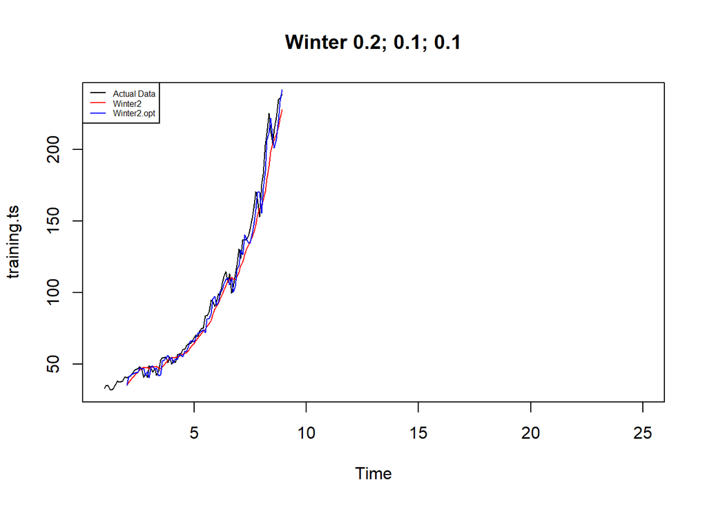

```r
plot(training.ts, main = "Winter 0.2; 0.1; 0.1", type = "l", col = "black",
     xlim = c(1, 25), pch = 12)
lines(xhat2, type = "l", col = "red")
lines(xhat2.opt, type = "l", col = "blue")
lines(forecast2, type = "l", col = "red")
lines(forecast2.opt, type = "l", col = "blue")
legend("topleft", c("Actual Data", expression(paste(Winter2)),
                   expression(paste(Winter2.opt))), cex = 0.5,
       col = c("black", "red", "blue"),lty = 1)
```

# Akurasi Data Latih

```r
# Akurasi Data Training
SSE2 <- winter2$SSE
SSE2
```

```
## [1] 5476.739
```

```r
MSE2 <- winter2$SSE/length(training.ts)
MSE2
```

```
## [1] 57.04936
```

```r
RMSE2 <- sqrt(MSE2)
RMSE2
```

```
## [1] 7.553103
```

```r
akurasi1 <- matrix(c(SSE2, MSE2, RMSE2))
akurasi1
```

```
##             [,1]
## [1,] 5476.738637
## [2,]   57.049361
## [3,]    7.553103
```

```r
row.names(akurasi1) <- c("SSE2", "MSE2", "RMSE2")
row.names(akurasi1)
```

```
## [1] "SSE2"  "MSE2"  "RMSE2"
```

```r
colnames(akurasi1) <- c("Akurasi lambda = 0.2")
colnames(akurasi1)
```

```
## [1] "Akurasi lambda = 0.2"
```

```r
akurasi1
```

```
##       Akurasi lambda = 0.2
## SSE2           5476.738637
## MSE2             57.049361
## RMSE2             7.553103
```

```r
SSE2.opt <- winter2.opt$SSE
SSE2.opt
```

```
## [1] 4049.145
```

```r
MSE2.opt <- winter2.opt$SSE/length(training.ts)
MSE2.opt
```

```
## [1] 42.1786
```

```r
RMSE2.opt <- sqrt(MSE2.opt)
RMSE2.opt
```

```
## [1] 6.494505
```

```r
akurasi1.opt <- matrix(c(SSE2.opt, MSE2.opt, RMSE2.opt))
akurasi1.opt
```

```
##             [,1]
## [1,] 4049.145445
## [2,]   42.178598
## [3,]    6.494505
```

```r
row.names(akurasi1.opt) <- c("SSE2.opt", "MSE2.opt", "RMSE2.opt")
row.names(akurasi1.opt)
```

```
## [1] "SSE2.opt"  "MSE2.opt"  "RMSE2.opt"
```

```r
colnames(akurasi1.opt) <- c("Akurasi")
colnames(akurasi1.opt)
```

```
## [1] "Akurasi"
```

```r
akurasi1.opt
```

```
##               Akurasi
## SSE2.opt  4049.145445
## MSE2.opt    42.178598
## RMSE2.opt    6.494505
```

```r
akurasi2.train = data.frame(Model_Winter = c("Winter 1", "winter2 optimal"),
                            Nilai_SSE = c(SSE2, SSE2.opt),
                            Nilai_MSE = c(MSE2, MSE2.opt), Nilai_RMSE = c(RMSE2, RMSE2.opt))
akurasi2.train
```

```
##      Model_Winter Nilai_SSE Nilai_MSE Nilai_RMSE
## 1        Winter 1  5476.739  57.04936   7.553103
## 2 winter2 optimal  4049.145  42.17860   6.494505
```

# Akurasi Data Uji

```r
# Akurasi Data Testing
forecast2 <- data.frame(forecast2)
forecast2
```

```
##         fit
## 1  249.6548
## 2  252.2353
## 3  261.4876
## 4  270.2107
## 5  275.7726
## 6  274.8815
## 7  276.2062
## 8  287.8900
## 9  289.0419
## 10 299.9773
## 11 298.3608
## 12 297.6954
## 13 315.2951
## 14 317.1321
## 15 327.3527
## 16 336.8738
## 17 342.4373
## 18 340.0185
## 19 340.3898
## 20 353.5177
## 21 353.7039
## 22 365.8575
## 23 362.7082
## 24 360.7658
```

```r
testing.ts <- data.frame(testing.ts)
testing.ts
```

```
##    testing.ts
## 1      253.40
## 2      251.23
## 3      269.61
## 4      286.36
## 5      302.87
## 6      282.12
## 7      331.36
## 8      335.13
## 9      335.35
## 10     310.41
## 11     296.40
## 12     309.37
## 13     277.71
## 14     275.20
## 15     256.39
## 16     277.82
## 17     258.87
## 18     235.41
## 19     234.60
## 20     253.87
## 21     243.08
## 22     248.00
## 23     250.76
## 24     286.52
```

```r
selisih2 <- forecast2-testing.ts
selisih2
```

```
##           fit
## 1   -3.745159
## 2    1.005284
## 3   -8.122390
## 4  -16.149291
## 5  -27.097381
## 6   -7.238546
## 7  -55.153783
## 8  -47.239998
## 9  -46.308090
## 10 -10.432694
## 11   1.960765
## 12 -11.674609
## 13  37.585113
## 14  41.932106
## 15  70.962748
## 16  59.053783
## 17  83.567302
## 18 104.608533
## 19 105.789783
## 20  99.647737
## 21 110.623867
## 22 117.857457
## 23 111.948246
## 24  74.245837
```

```r
SSEtesting2 <- sum(selisih2^2)
SSEtesting2
```

```
## [1] 103709.9
```

```r
MSEtesting2 <- SSEtesting2/length(testing.ts)
MSEtesting2
```

```
## [1] 103709.9
```

```r
forecast2.opt <- data.frame(forecast2.opt)
forecast2.opt
```

```
##         fit
## 1  249.7136
## 2  246.5500
## 3  249.2364
## 4  257.6962
## 5  266.2713
## 6  273.9892
## 7  274.6914
## 8  283.4785
## 9  280.2727
## 10 283.2875
## 11 278.8739
## 12 285.9223
## 13 298.4689
## 14 293.9170
## 15 296.3649
## 16 305.6685
## 17 315.0827
## 18 323.4597
## 19 323.5534
## 20 333.1671
## 21 328.6921
## 22 331.5332
## 23 325.7033
## 24 333.2727
```

```r
selisih2.opt <- forecast2.opt-testing.ts
selisih2.opt
```

```
##           fit
## 1   -3.686417
## 2   -4.679989
## 3  -20.373631
## 4  -28.663760
## 5  -36.598685
## 6   -8.130768
## 7  -56.668633
## 8  -51.651495
## 9  -55.077267
## 10 -27.122455
## 11 -17.526110
## 12 -23.447658
## 13  20.758907
## 14  18.716983
## 15  39.974917
## 16  27.848549
## 17  56.212725
## 18  88.049727
## 19  88.953440
## 20  79.297084
## 21  85.612145
## 22  83.533222
## 23  74.943281
## 24  46.752728
```

```r
SSEtesting2.opt <- sum(selisih2.opt^2)
SSEtesting2.opt
```

```
## [1] 63560.77
```

```r
MSEtesting2.opt <- SSEtesting2.opt/length(testing.ts)
MSEtesting2.opt
```

```
## [1] 63560.77
```